# Project: **Travel Destination Recommender**

1. Executive Summary
2. Introduction
3. Data Collection
   - 3.1. Importing Packages
   - 3.2. Data Preprocessing
   - 3.3. Cleaning the Data
4. Sentiment Analysis
   - 4.1. Checking the relationships between the independent variables and the dependent variable
   - 4.2. Data Visualisation
   - 4.3. Checking the data distribution
5. Feature Engineering
6. Model Development
7. Model Evaluation
8. Real-time Implementation

## Introduction

The aim of this project is to develop a travel destination recommender system that leverages data scraped from various travel websites such as TripAdvisor, Lonely Planet, and Yelp. By aggregating information on attractions, hotels, restaurants, and local experiences, the system will provide personalized recommendations based on user preferences, budget, and interests.

## Step 1: Choose Travel Websites

- TripAdvisor (https://www.tripadvisor.com/)
- Lonely Planet (https://www.lonelyplanet.com/)
- Yelp (https://www.yelp.com/)
- Booking.com (https://www.booking.com/)

### TripAdvisor (https://www.tripadvisor.com/)

TripAdvisor stands out as an ideal choice due to its comprehensive coverage of travel information. Boasting one of the largest repositories of user-generated reviews and ratings, it offers valuable insights into travelers' experiences and preferences. Moreover, TripAdvisor's attraction rankings based on popularity and user ratings make it an invaluable resource for identifying top destinations. With its global coverage spanning diverse destinations worldwide, it caters to a broad spectrum of travel interests and preferences.

### Lonely Planet (https://www.lonelyplanet.com/)

Lonely Planet emerges as a prime candidate for scraping travel data owing to its reputation for expert recommendations and curated travel guides. Renowned for its commitment to promoting authentic and off-the-beaten-path experiences, Lonely Planet offers travelers reliable insights into unique adventures. Its guides are not only informative but also provide in-depth cultural insights and historical background, enriching travelers' understanding of destinations. Additionally, Lonely Planet's specialized guides cater to various interests, including food, adventure, and cultural exploration, ensuring relevance to diverse traveler preferences.

### Yelp (https://www.yelp.com/)

Yelp is an excellent choice for scraping travel data, particularly regarding restaurant reviews and local business information. With a focus on providing comprehensive coverage of local businesses, including attractions, shops, and services, Yelp offers valuable information for travelers. Its user-generated content allows travelers to access authentic reviews and recommendations from fellow travelers and locals alike. Furthermore, Yelp's location-based search feature facilitates the discovery of nearby attractions, restaurants, and activities, streamlining the trip planning process for travelers.

### Booking.com (https://www.booking.com/)

Booking.com emerges as a suitable option for scraping accommodation-related data, given its extensive coverage of hotel and accommodation listings. As a leading platform for hotel bookings, Booking.com offers a vast selection of properties worldwide, catering to various budgets and preferences. The platform's user reviews and ratings provide valuable insights into the quality and guest experiences of accommodations, enabling travelers to make informed decisions. Additionally, Booking.com's range of booking options, including flexible cancellation policies and last-minute deals, enhances its appeal to travelers seeking convenience and flexibility in their bookings.

## Step 2: Identifying Data to Scrape

- Attractions (sights, landmarks, museums, parks)
- Hotels (ratings, prices, amenities)
- Restaurants (ratings, cuisines, prices)
- Local Experiences (tours, activities, events)
- User preferences (budget, interests, travel dates)

### Attractions (sights, landmarks, museums, parks)

Scraping data on attractions entails gathering information about notable sights, landmarks, museums, and parks in various destinations. These attractions serve as key points of interest for travelers, offering cultural, historical, and recreational experiences. By scraping data on attractions, the recommender system can provide travelers with insights into must-visit locations, including details on opening hours, admission fees, visitor reviews, and notable features.

### Hotels (ratings, prices, amenities)

Hotels constitute a crucial aspect of travel planning, providing accommodations for travelers during their trips. Scraping data on hotels involves gathering information on their ratings, prices, and amenities. Ratings and reviews from previous guests offer valuable insights into the quality and service standards of hotels, helping travelers make informed decisions. Additionally, pricing information enables travelers to compare options based on their budget constraints, while details on amenities such as Wi-Fi, breakfast, and parking facilities enhance the overall user experience.

### Restaurants (ratings, cuisines, prices)

Restaurants play a vital role in enhancing the travel experience by offering diverse culinary experiences and flavors unique to each destination. Scraping data on restaurants involves gathering information on their ratings, cuisines, and prices. User-generated ratings and reviews provide valuable feedback on the quality of food, service, and ambiance, aiding travelers in selecting dining options that align with their preferences. Moreover, details on cuisines and price ranges allow travelers to explore a variety of dining options that suit their tastes and budget.

### Local Experiences (tours, activities, events)

Local experiences encompass a wide range of tours, activities, and events that offer immersive and authentic cultural experiences for travelers. Scraping data on local experiences involves gathering information on guided tours, outdoor activities, cultural events, and entertainment options available in each destination. By providing insights into these experiences, the recommender system enables travelers to discover and participate in activities that align with their interests and preferences, enhancing their overall travel experience.

### User Preferences (budget, interests, travel dates)

User preferences constitute the foundation of personalized travel recommendations, guiding the selection of destinations and experiences that best suit each traveler's needs and preferences. Scraping data on user preferences involves gathering information on budget constraints, travel interests, and travel dates. By understanding travelers' budget limitations, interests such as adventure, history, or culinary exploration, and travel dates, the recommender system can tailor recommendations to match individual preferences, ensuring a customized and enjoyable travel experience for each user.

## Step 3: Set Up Your Environment

- Choose programming language (e.g., Python) and web scraping libraries (e.g., BeautifulSoup, requests)
- Install necessary libraries:

  ```
  pip install beautifulsoup4 requests
  ```

### Instant Data Scraper Web Extension

For this project, the Instant Data Scraper web extension was utilized as an alternative to traditional web scraping libraries like BeautifulSoup and requests. Instant Data Scraper is a browser extension available for Chrome and Firefox, designed specifically for scraping data from web pages with ease. By installing the extension, users gain access to a user-friendly interface that allows them to select and extract data directly from websites without writing code. This approach simplifies the process of data extraction, making it accessible to individuals without extensive programming knowledge. Additionally, the extension provides features for exporting scraped data in various formats, such as CSV or JSON, for further analysis and processing.

### Octoparse

In addition to the Instant Data Scraper web extension, Octoparse was employed as a web scraping tool for this project. Octoparse is a powerful and versatile web scraping software that enables users to extract data from websites using a visual point-and-click interface. With Octoparse, users can create scraping tasks by simply navigating through web pages and selecting the data they want to extract. The software offers advanced features such as automatic IP rotation, data export scheduling, and cloud-based extraction for handling large-scale scraping projects efficiently. Furthermore, Octoparse provides support for scraping dynamic and JavaScript-rendered web pages, ensuring compatibility with a wide range of websites and data sources.

```python
#| echo: true
#| code-fold: true
#| panel: input
import pandas as pd
from bertopic import BERTopic
from nltk.corpus import stopwords
import nltk
import matplotlib.pyplot as plt
import seaborn as sns
%matplotlib inline
from nltk.tokenize import word_tokenize
from bertopic import BERTopic
from nltk.corpus import stopwords
import string
import nltk
nltk.download('punkt')
```

```
True
```

## Step 4: Start Scraping

Now that we've set up our environment using web scraping tools like Instant Data Scraper and Octoparse, we can begin scraping data from each selected website. Instead of writing scripts, we'll utilize the intuitive interfaces provided by these tools to extract data seamlessly.

### Using Instant Data Scraper:

1. Launch the Instant Data Scraper web extension in your browser.
2. Navigate to the desired website, such as TripAdvisor or Lonely Planet.
3. Use the extension's point-and-click interface to select the data you want to scrape, such as top attractions in a city.
4. Configure the scraping settings, including pagination handling and data export options.
5. Run the scraper to extract the selected data from the website.
6. Export the scraped data in a suitable format, such as CSV or JSON, for further analysis.

### Using Octoparse:

1. Launch the Octoparse software on your computer.
2. Create a new scraping task and enter the URL of the target website.
3. Use Octoparse's visual workflow builder to define the extraction steps, such as navigating to specific pages and selecting data elements.
4. Configure advanced settings, such as automatic IP rotation and data export scheduling, as needed.
5. Run the scraping task to extract data from the website.
6. Review and verify the extracted data within the Octoparse interface.
7. Export the scraped data to your preferred format for analysis and processing.

By leveraging these web scraping tools, we can efficiently gather data from multiple websites without the need for writing complex scripts. This approach streamlines the scraping process and allows us to focus on refining and analyzing the extracted data for our travel destination recommender.

## Step 5: Refine Your Scripts

- Refine scripts to extract specific data like hotel details, restaurant reviews, and activity information.
- Handle pagination for websites with multiple pages of results.
- Adapt scripts to website structure changes.

**Must-See Attractions:**

I have chosen Lonely Planet for attractions in this project based on several factors. Lonely Planet is a well-known and respected travel guide publisher, making it a valuable source of information for travelers. Lonely Planet is detailed, and user-friendly information, making it easy to scrape data efficiently. Their guides cover a wide range of attractions, from popular landmarks to hidden gems, ensuring diverse recommendations. Users trust Lonely Planet's ratings and reviews, enhancing the credibility of your recommendation engine. Additionally, Lonely Planet's global coverage and inspirational content spark wanderlust, catering to a broad user base. By leveraging Lonely Planet's wealth of travel knowledge, your app can provide personalized and exciting suggestions for memorable travel experiences. Here quick summary of the data:

### Must-See Attractions

```python
#| echo: true
#| code-fold: true
#| panel: input
# Load data from CSV file
berlin = pd.read_csv('/Users/emredeveci/Desktop/data science/Travel Destination Recommender/data_mining/berlin_attractions - Sheet1.csv')
berlin.head()
```

|  | website1 | website2 | name | location | description | type | city |
| --- | --- | --- | --- | --- | --- | --- | --- |
| 0 | https://lp-cms-production.imgix.net/2019-06/d6... | https://www.lonelyplanet.com/germany/berline/m... | Museumsinsel | Museumsinsel & Alexanderplatz | Walk through ancient Babylon, meet an Egyptian... | must_see | Berlin |
| 1 | https://lp-cms-production.imgix.net/2021-08/sh... | https://www.lonelyplanet.com/germany/berline/m... | Neues Museum | Museumsinsel & Alexanderplatz | For over 60 years, not a soul was able to visi... | must_see | Berlin |
| 2 | https://lp-cms-production.imgix.net/2019-06/d5... | https://www.lonelyplanet.com/germany/berline/m... | Pergamonmuseum | Museumsinsel & Alexanderplatz | The Pergamonmuseum is one of Berlin’s most vis... | must_see | Berlin |
| 3 | https://lp-cms-production.imgix.net/2021-08/sh... | https://www.lonelyplanet.com/germany/berlin/fr... | East Side Gallery | Friedrichshain | The East Side Gallery is the embodiment of Ber... | must_see | Berlin |
| 4 | https://lp-cms-production.imgix.net/2024-02/Ge... | https://www.lonelyplanet.com/germany/berline/m... | Fernsehturm | Museumsinsel & Alexanderplatz | Germany's tallest structure, the TV Tower is a... | must_see | Berlin |

```python
#| echo: true
#| code-fold: true
#| panel: input
# Load data from CSV file
bremen = pd.read_csv('/Users/emredeveci/Desktop/data science/Travel Destination Recommender/data_mining/bremen_attractions - Sheet1.csv')
bremen.head()
```

|  | website1 | website2 | name | location | description | type | city |
| --- | --- | --- | --- | --- | --- | --- | --- |
| 0 | https://lonelyplanetstatic.imgix.net/marketing... | https://www.lonelyplanet.com/germany/lower-sax... | Herrenhäuser Gärten | Hanover | Proof that Hanover is not all buttoned-down bu... | must_see | Lower Saxony & Bremen |
| 1 | https://lp-cms-production.imgix.net/2019-06/2a... | https://www.lonelyplanet.com/germany/bergen-be... | Gedenkstätte Bergen-Belsen | Lower Saxony & Bremen | The Nazi-built camp at Bergen-Belsen began its... | must_see | Lower Saxony & Bremen |
| 2 | https://lonelyplanetstatic.imgix.net/marketing... | https://www.lonelyplanet.com/germany/lower-sax... | Schloss Marienburg | Lower Saxony & Bremen | Perched grandly above the Leine River, the neo... | must_see | Lower Saxony & Bremen |
| 3 | https://lonelyplanetstatic.imgix.net/marketing... | https://www.lonelyplanet.com/germany/bremen-ci... | Denkort Bunker Valentin | Bremen City | In 1943, the Nazis started construction of a m... | must_see | Lower Saxony & Bremen |
| 4 | https://lonelyplanetstatic.imgix.net/marketing... | https://www.lonelyplanet.com/germany/lower-sax... | Autostadt | Lower Saxony & Bremen | A hit with car buffs of all ages, Autostadt is... | must_see | Lower Saxony & Bremen |

```python
#| echo: true
#| code-fold: true
#| panel: input
# Load data from CSV file
hamburg = pd.read_csv('/Users/emredeveci/Desktop/data science/Travel Destination Recommender/data_mining/hamburg_attractions - Sheet1.csv')
hamburg.head()
```

|  | website1 | website2 | name | location | description | type | city |
| --- | --- | --- | --- | --- | --- | --- | --- |
| 0 | https://lp-cms-production.imgix.net/2019-06/fd... | https://www.lonelyplanet.com/germany/hamburg/a... | Mahnmal St-Nikolai | Altstadt | St Nikolai church was the world’s tallest buil... | must_see | Hamburg |
| 1 | https://lp-cms-production.imgix.net/2019-06/b7... | https://www.lonelyplanet.com/germany/hamburg/s... | Fischmarkt | St Pauli & Reeperbahn | Here's the perfect excuse to stay up all Satur... | must_see | Hamburg |
| 2 | https://lp-cms-production.imgix.net/2019-06/eb... | https://www.lonelyplanet.com/germany/hamburg/s... | Elbphilharmonie | Hamburg | Welcome to one of the most Europe's most excit... | must_see | Hamburg |
| 3 | https://lp-cms-production.imgix.net/2019-06/d7... | https://www.lonelyplanet.com/germany/hamburg/a... | Hamburger Kunsthalle | Altstadt | A treasure trove of art from the Renaissance t... | must_see | Hamburg |
| 4 | https://lonelyplanetstatic.imgix.net/marketing... | https://www.lonelyplanet.com/germany/hamburg/a... | Rathaus | Altstadt | With its spectacular coffered ceiling, Hamburg... | must_see | Hamburg |

```python
#| echo: true
#| code-fold: true
#| panel: input
# Load data from CSV file
munich = pd.read_csv('/Users/emredeveci/Desktop/data science/Travel Destination Recommender/data_mining/munich_attractions - Sheet1.csv')
munich.head()
```

|  | website1 | website2 | name | description | location | type | city |
| --- | --- | --- | --- | --- | --- | --- | --- |
| 0 | https://lp-cms-production.imgix.net/2019-06/c2... | https://www.lonelyplanet.com/germany/munich/ny... | Schloss Nymphenburg | This commanding palace and its lavish gardens ... | Munich | must_see | Munich |
| 1 | https://lp-cms-production.imgix.net/2019-06/ee... | https://www.lonelyplanet.com/germany/munich/al... | Residenzmuseum | Home to Bavaria's Wittelsbach rulers from 1508... | Munich | must_see | Munich |
| 2 | https://lp-cms-production.imgix.net/2019-06/3e... | https://www.lonelyplanet.com/germany/munich/ma... | Alte Pinakothek | Munich's main repository of Old European Maste... | Munich | must_see | Munich |
| 3 | https://lp-cms-production.imgix.net/2019-06/0d... | https://www.lonelyplanet.com/germany/munich/sc... | Englischer Garten | The sprawling English Garden is among Europe's... | Munich | must_see | Munich |
| 4 | https://lp-cms-production.imgix.net/2019-06/c9... | https://www.lonelyplanet.com/germany/munich/ma... | Pinakothek der Moderne | Germany's largest modern-art museum unites fou... | Munich | must_see | Munich |

```python
#| echo: true
#| code-fold: true
#| panel: input
# Concatenate the three dataframes along the rows (axis=0)
germany_df = pd.concat([bremen, berlin, hamburg,munich], ignore_index=True)

# Save the combined dataframe to a new CSV file
germany_df.to_csv('combined_dataset.csv', index=False)
germany_df.head()
```

|  | website1 | website2 | name | location | description | type | city |
| --- | --- | --- | --- | --- | --- | --- | --- |
| 0 | https://lonelyplanetstatic.imgix.net/marketing... | https://www.lonelyplanet.com/germany/lower-sax... | Herrenhäuser Gärten | Hanover | Proof that Hanover is not all buttoned-down bu... | must_see | Lower Saxony & Bremen |
| 1 | https://lp-cms-production.imgix.net/2019-06/2a... | https://www.lonelyplanet.com/germany/bergen-be... | Gedenkstätte Bergen-Belsen | Lower Saxony & Bremen | The Nazi-built camp at Bergen-Belsen began its... | must_see | Lower Saxony & Bremen |
| 2 | https://lonelyplanetstatic.imgix.net/marketing... | https://www.lonelyplanet.com/germany/lower-sax... | Schloss Marienburg | Lower Saxony & Bremen | Perched grandly above the Leine River, the neo... | must_see | Lower Saxony & Bremen |
| 3 | https://lonelyplanetstatic.imgix.net/marketing... | https://www.lonelyplanet.com/germany/bremen-ci... | Denkort Bunker Valentin | Bremen City | In 1943, the Nazis started construction of a m... | must_see | Lower Saxony & Bremen |
| 4 | https://lonelyplanetstatic.imgix.net/marketing... | https://www.lonelyplanet.com/germany/lower-sax... | Autostadt | Lower Saxony & Bremen | A hit with car buffs of all ages, Autostadt is... | must_see | Lower Saxony & Bremen |

```python
#| echo: true
#| code-fold: true
#| panel: input
# Filter out rows where type is 'to_stay' or 'to_eat'
filtered_df = germany_df[~germany_df['type'].isin(['to_stay', 'to_eat'])]
```

### Tour Recommendation

```python
#| echo: true
#| code-fold: true
#| panel: input
# Load data from CSV file
tour_bremen = pd.read_csv('/Users/emredeveci/Desktop/data science/Travel Destination Recommender/data_mining/bremen_tour - Sheet1.csv')
tour_bremen.head()
```

|  | website | name | score | reviews | type | duration | comment1 | price | group | city |
| --- | --- | --- | --- | --- | --- | --- | --- | --- | --- | --- |
| 0 | https://www.tripadvisor.com/AttractionProductR... | e-Scavenger hunt Bremen: Explore the city at y... | 4.0 of 5 bubbles | 15.0 | Audio Guides | 2–4 hours | Get to know Bremen in a unique and affordable ... | $34 | per group | bremen |
| 1 | https://www.tripadvisor.com/AttractionProductR... | Bremen : Private Walking Tour With A Tour Guid... | 3.0 of 5 bubbles | 2.0 | Historical Tours | 2–6 hours | Get to know the city through the eyes of a loc... | $52 | per adult | bremen |
| 2 | https://www.tripadvisor.com/AttractionProductR... | Bremen Schnoor Area Tour | 5.0 of 5 bubbles | 5.0 | Historical Tours | 1 hour | Explore with us the Schnoor area – a neighbour... | $24 | per adult | bremen |
| 3 | https://www.tripadvisor.com/AttractionProductR... | Bremen Private Walking Tour With A Professiona... | 5.0 of 5 bubbles | 1.0 | Walking Tours | 1–2 hours | Meetingpoint: In front of the Town Hall or Mee... | $224 | per group | bremen |
| 4 | https://www.tripadvisor.com/AttractionProductR... | Bremen - Private Historic Walking Tour | 5.0 of 5 bubbles | 1.0 | Historical Tours | 1–2 hours | Discover the city of Bremen, a major cultural ... | $321 | per group | bremen |

```python
#| echo: true
#| code-fold: true
#| panel: input
# Load data from CSV file
tour_hamburg = pd.read_csv('/Users/emredeveci/Desktop/data science/Travel Destination Recommender/data_mining/hamburg_tour - Sheet1.csv')
tour_hamburg.head()
```

|  | website | name | score | reviews | type | duration | comment1 | price | group | city |
| --- | --- | --- | --- | --- | --- | --- | --- | --- | --- | --- |
| 0 | https://www.tripadvisor.com/AttractionProductR... | The Local Tour of Hamburg Historic Centre | 5.0 of 5 bubbles | 784 | Historical Tours | 2 hours | Pay-What-You-Want tour with booking fee!\n\nWi... | $3 | per adult | hamburg |
| 1 | https://www.tripadvisor.com/AttractionProductR... | Private Small-Group Hamburg City Tour with a L... | 5.0 of 5 bubbles | 178 | Historical Tours | 3 hours | Welcome to our beloved Hamburg.\nI´m a former ... | $264 | per group | hamburg |
| 2 | https://www.tripadvisor.com/AttractionProductR... | Hop-on hop-off on the water with the Maritime ... | 4.0 of 5 bubbles | 63 | Day Cruises | 1–2 hours | A sightseeing harbor cruise with the Maritime ... | $22 | per adult | hamburg |
| 3 | https://www.tripadvisor.com/AttractionProductR... | Hamburg Dungeon Admission Ticket | 4.0 of 5 bubbles | 187 | Historical Tours | 1–2 hours | Experience 600 years of dark history - if you ... | $31 | per adult | hamburg |
| 4 | https://www.tripadvisor.com/AttractionProductR... | Hamburg 2-hour harbor tour on the beautiful Elbe | 3.5 of 5 bubbles | 21 | Historical Tours | 2 hours | We offer an extensive Hamburg XXL harbor tour ... | $38 | per adult | hamburg |

```python
#| echo: true
#| code-fold: true
#| panel: input
# Load data from CSV file
tour_berlin = pd.read_csv('/Users/emredeveci/Desktop/data science/Travel Destination Recommender/data_mining/berlin_tour - Sheet1.csv')
tour_berlin.head()
```

|  | website | name | score | reviews | type | duration | comment1 | price | group | city |
| --- | --- | --- | --- | --- | --- | --- | --- | --- | --- | --- |
| 0 | https://www.tripadvisor.com/AttractionProductR... | Discover Berlin Half-Day Walking Tour | 5.0 of 5 bubbles | 4,191 | Historical Tours | 3–4 hours | See many of Berlin's most important landmarks ... | $22 | per adult | berlin |
| 1 | https://www.tripadvisor.com/AttractionProductR... | River Cruise with Tour Guide in Berlin. Hadynski | 4.5 of 5 bubbles | 36 | On the Water | 1 hour | Enjoy our 1 hour river cruise through the old ... | $21 | per adult | berlin |
| 2 | https://www.tripadvisor.com/AttractionProductR... | Berlin Third Reich and Cold War 2-Hour Walking... | 5.0 of 5 bubbles | 124 | Historical Tours | 2 hours | Learn the tumultuous contemporary history of B... | $22 | per adult | berlin |
| 3 | https://www.tripadvisor.com/AttractionProductR... | Big Bus Berlin Hop-On Hop-Off Sightseeing Tour | 4.0 of 5 bubbles | 404 | Audio Guides | 2 hours | Enjoy this perfect introduction to Berlin on a... | $27 | per adult | berlin |
| 4 | https://www.tripadvisor.com/AttractionProductR... | Berlin Food Walking Tour With Secret Food Tours | 5.0 of 5 bubbles | 477 | Food & Drink | 3 hours | With so much great food in East Berlin, it can... | $105 | per adult | berlin |

```python
#| echo: true
#| code-fold: true
#| panel: input
# Load data from CSV file
tour_munich = pd.read_csv('/Users/emredeveci/Desktop/data science/Travel Destination Recommender/data_mining/munich_tour - Sheet1.csv')
tour_munich.head()
```

|  | website | name | score | reviews | type | duration | comment1 | price | group | city |
| --- | --- | --- | --- | --- | --- | --- | --- | --- | --- | --- |
| 0 | https://www.tripadvisor.com/AttractionProductR... | Neuschwanstein Castle and Linderhof VIP All-In... | 4.5 of 5 bubbles | 445 | Sightseeing Packages | 6+ hours | Leave Munich for a full-day tour to two royal ... | $215 | per adult | munich |
| 1 | https://www.tripadvisor.com/AttractionProductR... | Neuschwanstein Castle and Linderhof Palace Day... | 4.5 of 5 bubbles | 242 | Historical Tours | 6+ hours | Drive with an airconditioned, comfortable coac... | $76 | per adult | munich |
| 2 | https://www.tripadvisor.com/AttractionProductR... | Neuschwanstein Castle and Linderhof Palace Day... | 4.5 of 5 bubbles | 1,381 | Historical Tours | 6+ hours | Bavaria is famous for its fairy-tale castles, ... | $80 | per adult | munich |
| 3 | NaN | NaN | NaN | How to navigate Munich’s museums like a pro | Soccer fans, art lovers, and design nerds have... | Read now | NaN | NaN | NaN | munich |
| 4 | https://www.tripadvisor.com/AttractionProductR... | Dachau Concentration Camp Memorial Site Tour f... | 5.0 of 5 bubbles | 1,313 | Historical Tours | 5 hours | Visiting Germany’s Dachau Concentration Camp M... | $52 | per adult | munich |

```python
#| echo: true
#| code-fold: true
#| panel: input
# Concatenate the three dataframes along the rows (axis=0)
all_tours = pd.concat([tour_hamburg, tour_berlin, tour_bremen,tour_munich], ignore_index=True)

# Save the combined dataframe to a new CSV file
all_tours.to_csv('combined_dataset.csv', index=False)
all_tours.head()
```

|  | website | name | score | reviews | type | duration | comment1 | price | group | city |
| --- | --- | --- | --- | --- | --- | --- | --- | --- | --- | --- |
| 0 | https://www.tripadvisor.com/AttractionProductR... | The Local Tour of Hamburg Historic Centre | 5.0 of 5 bubbles | 784 | Historical Tours | 2 hours | Pay-What-You-Want tour with booking fee!\n\nWi... | $3 | per adult | hamburg |
| 1 | https://www.tripadvisor.com/AttractionProductR... | Private Small-Group Hamburg City Tour with a L... | 5.0 of 5 bubbles | 178 | Historical Tours | 3 hours | Welcome to our beloved Hamburg.\nI´m a former ... | $264 | per group | hamburg |
| 2 | https://www.tripadvisor.com/AttractionProductR... | Hop-on hop-off on the water with the Maritime ... | 4.0 of 5 bubbles | 63 | Day Cruises | 1–2 hours | A sightseeing harbor cruise with the Maritime ... | $22 | per adult | hamburg |
| 3 | https://www.tripadvisor.com/AttractionProductR... | Hamburg Dungeon Admission Ticket | 4.0 of 5 bubbles | 187 | Historical Tours | 1–2 hours | Experience 600 years of dark history - if you ... | $31 | per adult | hamburg |
| 4 | https://www.tripadvisor.com/AttractionProductR... | Hamburg 2-hour harbor tour on the beautiful Elbe | 3.5 of 5 bubbles | 21 | Historical Tours | 2 hours | We offer an extensive Hamburg XXL harbor tour ... | $38 | per adult | hamburg |

```python
#| echo: true
#| code-fold: true
#| panel: input
all_tours.info()
```

```
<class 'pandas.core.frame.DataFrame'>
RangeIndex: 1700 entries, 0 to 1699
Data columns (total 10 columns):
 #   Column    Non-Null Count  Dtype
---  ------    --------------  -----
 0   website   1682 non-null   object
 1   name      1682 non-null   object
 2   score     771 non-null    object
 3   reviews   792 non-null    object
 4   type      1700 non-null   object
 5   duration  1698 non-null   object
 6   comment1  1672 non-null   object
 7   price     1678 non-null   object
 8   group     1682 non-null   object
 9   city      1700 non-null   object
dtypes: object(10)
memory usage: 132.9+ KB
```

```python
#| echo: true
#| code-fold: true
#| panel: input
missing_values = all_tours.isnull().sum()
missing_values
```

```
website      18
name         18
score       929
reviews     908
type          0
duration      2
comment1     28
price        22
group        18
city          0
dtype: int64
```

```python
#| echo: true
#| code-fold: true
#| panel: input
# Drop rows where 'website' is NaN
all_tours = all_tours.dropna(subset=['website'])
```

```python
#| echo: true
#| code-fold: true
#| panel: input
# Now, let's convert 'score' to float
def extract_score(score_str):
    try:
        return float(score_str.split()[0])  # Take the first part of the string, convert to float
    except:
        return None

# Apply the function to 'score' column
all_tours['score'] = all_tours['score'].apply(extract_score)
```

```python
#| echo: true
#| code-fold: true
#| panel: input
all_tours.head()
```

|  | website | name | score | reviews | type | duration | comment1 | price | group | city |
| --- | --- | --- | --- | --- | --- | --- | --- | --- | --- | --- |
| 0 | https://www.tripadvisor.com/AttractionProductR... | The Local Tour of Hamburg Historic Centre | 5.0 | 784 | Historical Tours | 2 hours | Pay-What-You-Want tour with booking fee!\n\nWi... | $3 | per adult | hamburg |
| 1 | https://www.tripadvisor.com/AttractionProductR... | Private Small-Group Hamburg City Tour with a L... | 5.0 | 178 | Historical Tours | 3 hours | Welcome to our beloved Hamburg.\nI´m a former ... | $264 | per group | hamburg |
| 2 | https://www.tripadvisor.com/AttractionProductR... | Hop-on hop-off on the water with the Maritime ... | 4.0 | 63 | Day Cruises | 1–2 hours | A sightseeing harbor cruise with the Maritime ... | $22 | per adult | hamburg |
| 3 | https://www.tripadvisor.com/AttractionProductR... | Hamburg Dungeon Admission Ticket | 4.0 | 187 | Historical Tours | 1–2 hours | Experience 600 years of dark history - if you ... | $31 | per adult | hamburg |
| 4 | https://www.tripadvisor.com/AttractionProductR... | Hamburg 2-hour harbor tour on the beautiful Elbe | 3.5 | 21 | Historical Tours | 2 hours | We offer an extensive Hamburg XXL harbor tour ... | $38 | per adult | hamburg |

```python
#| echo: true
#| code-fold: true
#| panel: input
def convert_to_float(value):
    try:
        return float(value)
    except ValueError:
        return None
```

```python
all_tours['reviews'] = all_tours['reviews'].apply(convert_to_float)
```

```python
all_tours.head()
```

|  | website | name | score | reviews | type | duration | comment1 | price | group | city |
| --- | --- | --- | --- | --- | --- | --- | --- | --- | --- | --- |
| 0 | https://www.tripadvisor.com/AttractionProductR... | The Local Tour of Hamburg Historic Centre | 5.0 | 784.0 | Historical Tours | 2 hours | Pay-What-You-Want tour with booking fee!\n\nWi... | $3 | per adult | hamburg |
| 1 | https://www.tripadvisor.com/AttractionProductR... | Private Small-Group Hamburg City Tour with a L... | 5.0 | 178.0 | Historical Tours | 3 hours | Welcome to our beloved Hamburg.\nI´m a former ... | $264 | per group | hamburg |
| 2 | https://www.tripadvisor.com/AttractionProductR... | Hop-on hop-off on the water with the Maritime ... | 4.0 | 63.0 | Day Cruises | 1–2 hours | A sightseeing harbor cruise with the Maritime ... | $22 | per adult | hamburg |
| 3 | https://www.tripadvisor.com/AttractionProductR... | Hamburg Dungeon Admission Ticket | 4.0 | 187.0 | Historical Tours | 1–2 hours | Experience 600 years of dark history - if you ... | $31 | per adult | hamburg |
| 4 | https://www.tripadvisor.com/AttractionProductR... | Hamburg 2-hour harbor tour on the beautiful Elbe | 3.5 | 21.0 | Historical Tours | 2 hours | We offer an extensive Hamburg XXL harbor tour ... | $38 | per adult | hamburg |

```python
#| echo: true
#| code-fold: true
#| panel: input
all_tours.info()
```

```
<class 'pandas.core.frame.DataFrame'>
Index: 1682 entries, 0 to 1699
Data columns (total 10 columns):
 #   Column    Non-Null Count  Dtype
---  ------    --------------  -----
 0   website   1682 non-null   object
 1   name      1682 non-null   object
 2   score     771 non-null    float64
 3   reviews   764 non-null    float64
 4   type      1682 non-null   object
 5   duration  1682 non-null   object
 6   comment1  1672 non-null   object
 7   price     1678 non-null   object
 8   group     1682 non-null   object
 9   city      1682 non-null   object
dtypes: float64(2), object(8)
memory usage: 144.5+ KB
```

```python
#| echo: true
#| code-fold: true
#| panel: input
# Now, let's convert 'price' to float, handling non-numeric values
def convert_price_to_float(price_str):
    try:
        # Remove non-numeric characters and convert to float
        return float(''.join(filter(str.isdigit, str(price_str))))
    except ValueError:
        return None
```

```python
#| echo: true
#| code-fold: true
#| panel: input
# Apply the function to 'price' column
all_tours['price'] = all_tours['price'].apply(convert_price_to_float)
```

```python
#| echo: true
#| code-fold: true
#| panel: input
all_tours.info()
```

```
<class 'pandas.core.frame.DataFrame'>
Index: 1682 entries, 0 to 1699
Data columns (total 10 columns):
 #   Column    Non-Null Count  Dtype
---  ------    --------------  -----
 0   website   1682 non-null   object
 1   name      1682 non-null   object
 2   score     771 non-null    float64
 3   reviews   764 non-null    float64
 4   type      1682 non-null   object
 5   duration  1682 non-null   object
 6   comment1  1672 non-null   object
 7   price     1675 non-null   float64
 8   group     1682 non-null   object
 9   city      1682 non-null   object
dtypes: float64(3), object(7)
memory usage: 144.5+ KB
```

```python
#| echo: true
#| code-fold: true
#| panel: input
# Create a new column 'price_category' based on 'price' ranges
def categorize_price(price):
    if price <= 50:
        return 'Low'
    elif 50 < price <= 300:
        return 'Moderate'
    else:
        return 'High'
```

```python
#| echo: true
#| code-fold: true
#| panel: input
# Apply the function to create the 'price_category' column
all_tours['price_category'] = all_tours['price'].apply(categorize_price)

# Now the "price_category" column will have these categories
# You can then analyze or plot based on these categories
price_counts = all_tours['price_category'].value_counts()
```

```python
print(price_counts)
```

```
price_category
Moderate    788
High        552
Low         342
Name: count, dtype: int64
```

### Restaurant Data

```python
#| echo: true
#| code-fold: true
#| panel: input
# Load data from CSV file
df_1 = pd.read_csv('/Users/emredeveci/Desktop/data science/Travel Destination Recommender/data_mining/rest_berlin - Sheet1.csv')
df_1.head()
```

|  | website | name | score | reviews | type | price | comment | comment2 | city |
| --- | --- | --- | --- | --- | --- | --- | --- | --- | --- |
| 0 | https://www.tripadvisor.com/Restaurant_Review-... | 26 Shibuya | 3.5 of 5 bubbles | 32 reviews | Japanese, Seafood | $$ - $$$ | If you want to try or experience Japanese food... | Amazing | berlin |
| 1 | https://www.tripadvisor.com/Restaurant_Review-... | 1. Focaccino | 4.5 of 5 bubbles | 788 reviews | Italian, Sicilian | $$ - $$$ | Our server Anneka was exceptional and the owne... | Delicious meal - great atmosphere | berlin |
| 2 | https://www.tripadvisor.com/Restaurant_Review-... | 2. Restaurant Buschbeck's | 5.0 of 5 bubbles | 392 reviews | German, European | $$ - $$$ | ... pasta with either salmon or & venison ste... | Me and my partner really had a good Time... | berlin |
| 3 | https://www.tripadvisor.com/Restaurant_Review-... | 3. Bantabaa | 5.0 of 5 bubbles | 89 reviews | African, Healthy | $$ - $$$ | Rich sauces, excellent options | Warm and | berlin |
| 4 | https://www.tripadvisor.com/Restaurant_Review-... | 4. Café Couscous - Vege | 5.0 of 5 bubbles | 140 reviews | Mediterranean, Healthy | $ | The wrap was super fresh and looks very good. ... | I ordered a burrito with , hallo... | berlin |

```python
#| echo: true
#| code-fold: true
#| panel: input
# Load data from CSV file
df_2 = pd.read_csv('/Users/emredeveci/Desktop/data science/Travel Destination Recommender/data_mining/rest_bremen - Sheet1.csv')
df_2.head()
```

|  | website | name | score | reviews | type | price | comment | comment2 | city |
| --- | --- | --- | --- | --- | --- | --- | --- | --- | --- |
| 0 | https://www.tripadvisor.com/Restaurant_Review-... | 1. Teestuebchen im Schnoor | 4.5 of 5 bubbles | 374 reviews | German, Cafe | $$ - $$$ | Great experience for lunch in a very atmosphe... | ... any rush to finish my tea and ! | bremen |
| 1 | https://www.tripadvisor.com/Restaurant_Review-... | 2. Fisherman's Seafood Bremen | 4.5 of 5 bubbles | 418 reviews | German, Seafood | $$ - $$$ | The fish soup and the special dish of fish, wi... | Excellent seafood restaurant with a lot of cho... | bremen |
| 2 | https://www.tripadvisor.com/Restaurant_Review-... | 3. Kleiner Olymp | 4.5 of 5 bubbles | 661 reviews | German, European | $$ - $$$ | This restaurant, which is known for offering l... | Good experience in Bremen | bremen |
| 3 | https://www.tripadvisor.com/Restaurant_Review-... | 4. Muchos Más | 4.5 of 5 bubbles | 473 reviews | Bar, Spanish | $$ - $$$ | Order it at the bar and once your name gets ca... | Original Spanish | bremen |
| 4 | https://www.tripadvisor.com/Restaurant_Review-... | 5. 1885 die Burger | 4.5 of 5 bubbles | 480 reviews | American, Fast Food | $$ - $$$ | The meat was really good and juicy, cooked med... | Vacation in Bremen | bremen |

```python
#| echo: true
#| code-fold: true
#| panel: input
# Load data from CSV file
df_3 = pd.read_csv('/Users/emredeveci/Desktop/data science/Travel Destination Recommender/data_mining/rest_hamburg - Sheet1.csv')
df_3.head()
```

|  | website | name | score | reviews | type | price | comment | comment2 | city |
| --- | --- | --- | --- | --- | --- | --- | --- | --- | --- |
| 0 | https://www.tripadvisor.com/Restaurant_Review-... | Rio Grande Blankenese | 4.5 of 5 bubbles | 78 reviews | European, Central European | $$ - $$$ | The price level for this quality meat is very ... | Worth a train ride out of the city | hamburg |
| 1 | https://www.tripadvisor.com/Restaurant_Review-... | 1. Le Golden Igel Tapas | 5.0 of 5 bubbles | 278 reviews | Mediterranean, European | $$ - $$$ | Nice place to go- always recommend; nice atmos... | The best food and staff in Germany | hamburg |
| 2 | https://www.tripadvisor.com/Restaurant_Review-... | 2. Rossio \| Tapas e Vinho | 5.0 of 5 bubbles | 159 reviews | Spanish, Portuguese | $$ - $$$ | My husband and I had a wonderful dinner at Caf... | A Place your need to go!! | hamburg |
| 3 | https://www.tripadvisor.com/Restaurant_Review-... | 3. La Paz Tapas & Wine Bar | 5.0 of 5 bubbles | 254 reviews | Mediterranean, European | $$ - $$$ | The large outside seating is very comfy. The s... | Delicious food, warm, romantic ambience | hamburg |
| 4 | https://www.tripadvisor.com/Restaurant_Review-... | 4. Stadtsalat | 5.0 of 5 bubbles | 128 reviews | International, Contemporary | $$ - $$$ | Stadtsalat offers modern, healthy and light lu... | Very fresh and very modern | hamburg |

```python
#| echo: true
#| code-fold: true
#| panel: input
# Load data from CSV file
df_4 = pd.read_csv('/Users/emredeveci/Desktop/data science/Travel Destination Recommender/data_mining/rest_munich - Sheet1.csv')
df_4.head()
```

|  | website | name | score | reviews | type | price | comment | comment2 | city |
| --- | --- | --- | --- | --- | --- | --- | --- | --- | --- |
| 0 | https://www.tripadvisor.com/Restaurant_Review-... | 1. Little London Bar & Grill | 4.5 of 5 bubbles | 1,483 reviews | Steakhouse, Barbecue | $$$$ | ... and it was all delicious, especially the b... | filet mignon | munich |
| 1 | https://www.tripadvisor.com/Restaurant_Review-... | 2. Cevicheria Pez | 4.5 of 5 bubbles | 408 reviews | Peruvian, Seafood | $$ - $$$ | We have ceviche to start, one with truffle an... | salmon | munich |
| 2 | https://www.tripadvisor.com/Restaurant_Review-... | 3. Chopan Schwabing | 5.0 of 5 bubbles | 597 reviews | Healthy, Middle Eastern | $$ - $$$ | The were delicious and the pumpkin starter wa... | lamb skewers | munich |
| 3 | https://www.tripadvisor.com/Restaurant_Review-... | 4. Trattoria Da Fausto | 4.5 of 5 bubbles | 1,584 reviews | Italian, Seafood | $$ - $$$ | She requested Italian and the hotel desk was q... | NaN | munich |
| 4 | https://www.tripadvisor.com/Restaurant_Review-... | 5. Trattoria Il Buco | 5.0 of 5 bubbles | 190 reviews | Italian, Pizza | $$ - $$$ | Very cozy Restaurant with high quality food. G... | NaN | munich |

```python
#| echo: true
#| code-fold: true
#| panel: input
# Concatenate the three dataframes along the rows (axis=0)
combined_df = pd.concat([df_1, df_2, df_3,df_4], ignore_index=True)

# Save the combined dataframe to a new CSV file
combined_df.to_csv('combined_dataset.csv', index=False)
combined_df.head()
```

|  | website | name | score | reviews | type | price | comment | comment2 | city |
| --- | --- | --- | --- | --- | --- | --- | --- | --- | --- |
| 0 | https://www.tripadvisor.com/Restaurant_Review-... | 26 Shibuya | 3.5 of 5 bubbles | 32 reviews | Japanese, Seafood | $$ - $$$ | If you want to try or experience Japanese food... | Amazing | berlin |
| 1 | https://www.tripadvisor.com/Restaurant_Review-... | 1. Focaccino | 4.5 of 5 bubbles | 788 reviews | Italian, Sicilian | $$ - $$$ | Our server Anneka was exceptional and the owne... | Delicious meal - great atmosphere | berlin |
| 2 | https://www.tripadvisor.com/Restaurant_Review-... | 2. Restaurant Buschbeck's | 5.0 of 5 bubbles | 392 reviews | German, European | $$ - $$$ | ... pasta with either salmon or & venison ste... | Me and my partner really had a good Time... | berlin |
| 3 | https://www.tripadvisor.com/Restaurant_Review-... | 3. Bantabaa | 5.0 of 5 bubbles | 89 reviews | African, Healthy | $$ - $$$ | Rich sauces, excellent options | Warm and | berlin |
| 4 | https://www.tripadvisor.com/Restaurant_Review-... | 4. Café Couscous - Vege | 5.0 of 5 bubbles | 140 reviews | Mediterranean, Healthy | $ | The wrap was super fresh and looks very good. ... | I ordered a burrito with , hallo... | berlin |

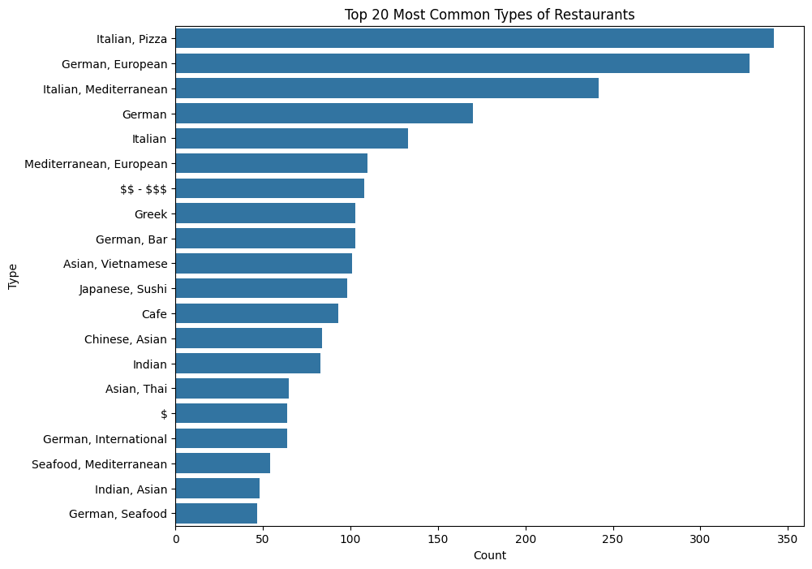

```python
#| echo: true
#| code-fold: true
#| panel: input
# Get the top 20 most common types
top_20_types = combined_df['type'].value_counts().head(20).index

plt.figure(figsize=(10, 8))
sns.countplot(y='type', data=combined_df, order=top_20_types)
plt.title('Top 20 Most Common Types of Restaurants')
plt.xlabel('Count')
plt.ylabel('Type')
plt.show()
```

```python
#| echo: true
#| code-fold: true
#| panel: input
combined_df.head()
```

|  | website | name | score | reviews | type | price | comment | comment2 | city |
| --- | --- | --- | --- | --- | --- | --- | --- | --- | --- |
| 0 | https://www.tripadvisor.com/Restaurant_Review-... | 26 Shibuya | 3.5 of 5 bubbles | 32 reviews | Japanese, Seafood | $$ - $$$ | If you want to try or experience Japanese food... | Amazing | berlin |
| 1 | https://www.tripadvisor.com/Restaurant_Review-... | 1. Focaccino | 4.5 of 5 bubbles | 788 reviews | Italian, Sicilian | $$ - $$$ | Our server Anneka was exceptional and the owne... | Delicious meal - great atmosphere | berlin |
| 2 | https://www.tripadvisor.com/Restaurant_Review-... | 2. Restaurant Buschbeck's | 5.0 of 5 bubbles | 392 reviews | German, European | $$ - $$$ | ... pasta with either salmon or & venison ste... | Me and my partner really had a good Time... | berlin |
| 3 | https://www.tripadvisor.com/Restaurant_Review-... | 3. Bantabaa | 5.0 of 5 bubbles | 89 reviews | African, Healthy | $$ - $$$ | Rich sauces, excellent options | Warm and | berlin |
| 4 | https://www.tripadvisor.com/Restaurant_Review-... | 4. Café Couscous - Vege | 5.0 of 5 bubbles | 140 reviews | Mediterranean, Healthy | $ | The wrap was super fresh and looks very good. ... | I ordered a burrito with , hallo... | berlin |

```python
#| echo: true
#| code-fold: true
#| panel: input
unique_types = combined_df['type'].unique()
```

```python
#| echo: true
#| code-fold: true
#| panel: input
unique_types
```

```
array(['Japanese, Seafood', 'Italian, Sicilian', 'German, European',
       'African, Healthy', 'Mediterranean, Healthy', 'European, Fusion',
       'Sushi, Asian', 'German, Bar', 'Mediterranean, European',
       'Bar, Eastern European', 'American, Fast Food', 'Indian, Asian',
       'Italian, Mediterranean', 'Italian, Seafood',
       'Cafe, International', 'Fast Food, Healthy', 'International',
       'Cafe, European', 'Caribbean, Latin', 'Italian, Pizza',
       'Middle Eastern, Arabic', 'Chinese, Asian', 'Italian',
       'Seafood, Mediterranean', 'International, European',
       'German, Central European', 'Indian, Grill', 'Indian, Healthy',
       'International, Contemporary', 'German, International',
       'German, Grill', 'Italian, Wine Bar', 'Mediterranean, Barbecue',
       'Asian, Fusion', 'French, European', 'Asian, Vietnamese',
       'American, Bar', 'American', 'Japanese, Steakhouse', 'Seafood',
       'Asian, Indonesian', 'Fusion, Healthy',
       'Caribbean, Cajun & Creole', 'European, Central European',
       'Seafood, International', 'Mediterranean, Spanish',
       'German, Diner', 'Indian', 'Austrian, European', 'Japanese, Asian',
       'Bar, Mediterranean', 'German', 'German, Austrian',
       'International, Russian', 'European, Contemporary',
       'German, Fast Food', 'Lebanese, Mediterranean', 'Bar, European',
       'Indian, Bar', 'Mediterranean, Middle Eastern',
       'Fast Food, European', 'International, Fusion', 'Japanese, Sushi',
       'Asian, Dining bars', 'Contemporary, Fusion',
       'Steakhouse, Barbecue', 'French, German', 'German, Brew Pub',
       'Asian, Thai', 'Brazilian, Grill', 'Cafe, Healthy', 'European',
       'American, Steakhouse', 'International, Grill', 'Bar, Seafood',
       'Japanese, Soups', 'German, Cafe', '$$$$', 'Steakhouse, Grill',
       'Mexican, Latin', 'German, Contemporary', 'French, Cafe',
       'Fast Food', 'African, Diner', 'French, International',
       'Asian, Korean', 'Israeli', 'Barbecue, Asian', 'Healthy',
       'Bar, International', 'European, Russian', 'Fast Food, Turkish',
       'Pub', 'American, German', 'American, Barbecue', 'Asian, Tibetan',
       'Peruvian, Fusion', 'Grill, Diner', 'Healthy, Street Food',
       'Lebanese, Cafe', 'Mediterranean, Turkish', 'Asian, Grill',
       'European, Croatian', 'Mexican, American', 'German, Seafood',
       'Bar, Spanish', 'Italian, European', 'Italian, Austrian',
       'Bar, Central European', 'Steakhouse, International', 'Grill',
       'Cafe', 'Italian, Steakhouse', 'Middle Eastern',
       'European, Middle Eastern', 'Thai', 'Steakhouse, German',
```

[output cut: 91 more lines]

```
       'European, Asian', 'German, Beer restaurants',
       'Pizza, International', 'Cafe, Central European', 'Greek, Healthy',
       'Italian, Deli', 'Brazilian, Cafe', 'Diner', 'Swiss, Cafe',
       'Greek, Georgian', 'Bar, Wine Bar', 'Mexican, German',
       'African, Sushi', 'Mediterranean, Portuguese',
       'Italian, Contemporary', 'French, Mexican', 'Cafe, Mediterranean',
       'Barbecue, European', 'Japanese, Mediterranean', 'German, Swiss',
       'Chinese, International', 'Deli, Eastern European',
       'Indian, Seafood', 'Cafe, Soups', 'Vietnamese, Japanese Fusion',
       'French, Asian', 'Bars & Pubs, Asian', 'International, Diner',
       'Japanese, European', 'Italian, Tuscan', 'German, Greek',
       'French, Japanese', 'American, Mediterranean', 'African, Nigerian',
       'Cafe, Sushi', 'Indian, Diner', 'Bar, Healthy', 'Mexican, Bar',
       'Mexican, Fast Food', 'Italian, Turkish', 'Japanese, Vietnamese',
       'Mediterranean, Pub', 'Bars & Pubs, Cafe'], dtype=object)
```

```python
#| echo: true
#| code-fold: true
#| panel: input
# Get the top 20 most common types
top_20_types = combined_df['type'].value_counts().head(20).index
```

```python
#| echo: true
#| code-fold: true
#| panel: input
top_20_types
```

```
Index(['Italian, Pizza', 'German, European', 'Italian, Mediterranean',
       'German', 'Italian', 'Mediterranean, European', '$$ - $$$', 'Greek',
       'German, Bar', 'Asian, Vietnamese', 'Japanese, Sushi', 'Cafe',
       'Chinese, Asian', 'Indian', 'Asian, Thai', '$', 'German, International',
       'Seafood, Mediterranean', 'Indian, Asian', 'German, Seafood'],
      dtype='object', name='type')
```

```python
#| echo: true
#| code-fold: true
#| panel: input
filtered_rest = combined_df[(combined_df['type'] != '$$ - $$$') & (combined_df['type'] != '$') & (combined_df['type'] != '$$$$')]
```

```python
#| echo: true
#| code-fold: true
#| panel: input
filtered_rest
```

|  | website | name | score | reviews | type | price | comment | comment2 | city |
| --- | --- | --- | --- | --- | --- | --- | --- | --- | --- |
| 0 | https://www.tripadvisor.com/Restaurant_Review-... | 26 Shibuya | 3.5 of 5 bubbles | 32 reviews | Japanese, Seafood | $$ - $$$ | If you want to try or experience Japanese food... | Amazing | berlin |
| 1 | https://www.tripadvisor.com/Restaurant_Review-... | 1. Focaccino | 4.5 of 5 bubbles | 788 reviews | Italian, Sicilian | $$ - $$$ | Our server Anneka was exceptional and the owne... | Delicious meal - great atmosphere | berlin |
| 2 | https://www.tripadvisor.com/Restaurant_Review-... | 2. Restaurant Buschbeck's | 5.0 of 5 bubbles | 392 reviews | German, European | $$ - $$$ | ... pasta with either salmon or & venison ste... | Me and my partner really had a good Time... | berlin |
| 3 | https://www.tripadvisor.com/Restaurant_Review-... | 3. Bantabaa | 5.0 of 5 bubbles | 89 reviews | African, Healthy | $$ - $$$ | Rich sauces, excellent options | Warm and | berlin |
| 4 | https://www.tripadvisor.com/Restaurant_Review-... | 4. Café Couscous - Vege | 5.0 of 5 bubbles | 140 reviews | Mediterranean, Healthy | $ | The wrap was super fresh and looks very good. ... | I ordered a burrito with , hallo... | berlin |
| ... | ... | ... | ... | ... | ... | ... | ... | ... | ... |
| 4827 | https://www.tripadvisor.com/Restaurant_Review-... | 1976. Sushi Saku | 4.5 of 5 bubbles | 3 reviews | Japanese, Peruvian | NaN | Amazing, mesmerising sushi that will remain in... | NaN | munich |
| 4828 | https://www.tripadvisor.com/Restaurant_Review-... | 1977. Sushi Cam | 4.5 of 5 bubbles | 3 reviews | Sushi | NaN | Super Sushiladen mit super Besitzern | NaN | munich |
| 4829 | https://www.tripadvisor.com/Restaurant_Review-... | 1978. Kugler Alm | 3.5 of 5 bubbles | 114 reviews | German, Central European | $$ - $$$ | The potato salad was homemade and also very de... | NaN | munich |
| 4830 | https://www.tripadvisor.com/Restaurant_Review-... | 1979. Die Schokoladengalerie | 5.0 of 5 bubbles | 5 reviews | Cafe | $$ - $$$ | Schokolade satt | NaN | munich |
| 4831 | https://www.tripadvisor.com/Restaurant_Review-... | 1980. Cafe Hohenbrunn Restaurant & Bar | 4.0 of 5 bubbles | 13 reviews | Bars & Pubs, Cafe | NaN | Nice and quick service, good menu cart and pol... | NaN | munich |

4647 rows × 9 columns

```python
top_20_types = filtered_rest['type'].value_counts().head(20)
```

```python
top_20_types.head()
```

```
type
Italian, Pizza            342
German, European          328
Italian, Mediterranean    242
German                    170
Italian                   133
Name: count, dtype: int64
```

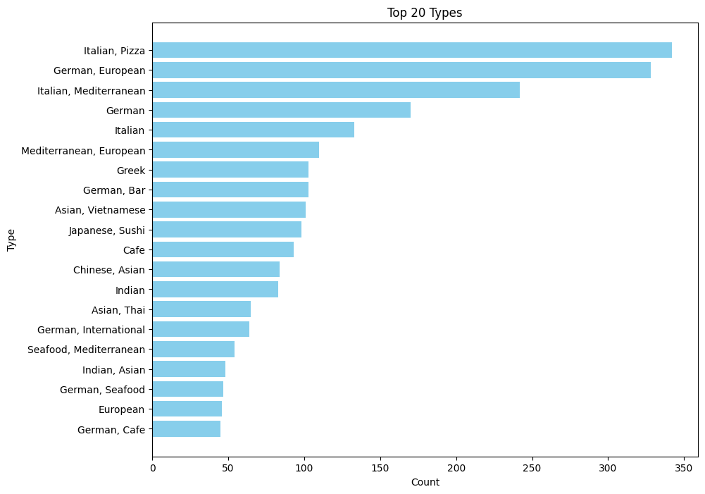

```python
#| echo: true
#| code-fold: true
#| panel: input
# Extract top 20 types and their counts
top_20_types = top_20_types.reset_index()
types = top_20_types['type']
counts = top_20_types['count']

# Plot the distribution of top 20 types
plt.figure(figsize=(10, 8))
plt.barh(types, counts, color='skyblue')
plt.xlabel('Count')
plt.ylabel('Type')
plt.title('Top 20 Types')
plt.gca().invert_yaxis()  # Invert y-axis to have the highest count at the top
plt.show()
```

```python
#| echo: true
#| code-fold: true
#| panel: input
filtered_rest
```

|  | website | name | score | reviews | type | price | comment | comment2 | city |
| --- | --- | --- | --- | --- | --- | --- | --- | --- | --- |
| 0 | https://www.tripadvisor.com/Restaurant_Review-... | 26 Shibuya | 3.5 of 5 bubbles | 32 reviews | Japanese, Seafood | $$ - $$$ | If you want to try or experience Japanese food... | Amazing | berlin |
| 1 | https://www.tripadvisor.com/Restaurant_Review-... | 1. Focaccino | 4.5 of 5 bubbles | 788 reviews | Italian, Sicilian | $$ - $$$ | Our server Anneka was exceptional and the owne... | Delicious meal - great atmosphere | berlin |
| 2 | https://www.tripadvisor.com/Restaurant_Review-... | 2. Restaurant Buschbeck's | 5.0 of 5 bubbles | 392 reviews | German, European | $$ - $$$ | ... pasta with either salmon or & venison ste... | Me and my partner really had a good Time... | berlin |
| 3 | https://www.tripadvisor.com/Restaurant_Review-... | 3. Bantabaa | 5.0 of 5 bubbles | 89 reviews | African, Healthy | $$ - $$$ | Rich sauces, excellent options | Warm and | berlin |
| 4 | https://www.tripadvisor.com/Restaurant_Review-... | 4. Café Couscous - Vege | 5.0 of 5 bubbles | 140 reviews | Mediterranean, Healthy | $ | The wrap was super fresh and looks very good. ... | I ordered a burrito with , hallo... | berlin |
| ... | ... | ... | ... | ... | ... | ... | ... | ... | ... |
| 4827 | https://www.tripadvisor.com/Restaurant_Review-... | 1976. Sushi Saku | 4.5 of 5 bubbles | 3 reviews | Japanese, Peruvian | NaN | Amazing, mesmerising sushi that will remain in... | NaN | munich |
| 4828 | https://www.tripadvisor.com/Restaurant_Review-... | 1977. Sushi Cam | 4.5 of 5 bubbles | 3 reviews | Sushi | NaN | Super Sushiladen mit super Besitzern | NaN | munich |
| 4829 | https://www.tripadvisor.com/Restaurant_Review-... | 1978. Kugler Alm | 3.5 of 5 bubbles | 114 reviews | German, Central European | $$ - $$$ | The potato salad was homemade and also very de... | NaN | munich |
| 4830 | https://www.tripadvisor.com/Restaurant_Review-... | 1979. Die Schokoladengalerie | 5.0 of 5 bubbles | 5 reviews | Cafe | $$ - $$$ | Schokolade satt | NaN | munich |
| 4831 | https://www.tripadvisor.com/Restaurant_Review-... | 1980. Cafe Hohenbrunn Restaurant & Bar | 4.0 of 5 bubbles | 13 reviews | Bars & Pubs, Cafe | NaN | Nice and quick service, good menu cart and pol... | NaN | munich |

4647 rows × 9 columns

```python
#| echo: true
#| code-fold: true
#| panel: input
# Replace the unique values with more descriptive categories
filtered_rest["price_category"] = filtered_rest["price"].replace({
    '$$ - $$$': 'Moderate',
    '$': 'Low',
    '$$$$': 'High'
})

# Now the "price_category" column will have these categories
# You can then analyze or plot based on these categories
price_counts = filtered_rest["price_category"].value_counts()

# Display the count of items in each price category
print(price_counts)
```

```
price_category
Moderate    3108
Low          725
High         283
Name: count, dtype: int64
```

```python
filtered_rest["score"] = filtered_rest["score"].str.replace(' of 5 bubbles', '').astype(float)
```

```python
def remove_missing_data_convert_reviews(df):
    # Remove rows with missing data
    df.dropna(inplace=True)

    # Convert 'reviews' column to float
    df['reviews'] = df['reviews'].astype(float)

    return df
```

```python
# filtered_rest = remove_missing_data_convert_reviews(filtered_rest)
```

```python
def recommend_restaurant(budget):
    # Clean 'reviews' column
    if budget <= 1000:
        # Filter restaurants in the low price category
        low_price_restaurants = filtered_rest[filtered_rest['price_category'] == 'Low']

        # Get top 5 restaurants with the highest score in the low price category
        top_low_price_restaurants = low_price_restaurants.nlargest(5, 'score')

        return top_low_price_restaurants

    elif 1000 < budget <= 10000:
        # Filter restaurants in the moderate price category
        moderate_price_restaurants = filtered_rest[filtered_rest['price_category'] == 'Moderate']

        # Get top 5 restaurants with the highest score in the moderate price category
        top_moderate_price_restaurants = moderate_price_restaurants.nlargest(5, 'score')

        return top_moderate_price_restaurants

    else:
        # Filter restaurants in the high price category
        high_price_restaurants = filtered_rest[filtered_rest['price_category'] == 'High']

        # Get top 5 restaurants with the highest score in the high price category
        top_high_price_restaurants = high_price_restaurants.nlargest(5, 'score')

        return top_high_price_restaurants
```

```python
# Example usage
budget = 1200  # User's budget in euros
top_restaurants = recommend_restaurant(budget)
```

```python
#| echo: true
#| code-fold: true
#| panel: input
print("Top 5 Restaurants based on Budget:")
print(top_restaurants)
```

```
Top 5 Restaurants based on Budget:
                                              website  \
2   https://www.tripadvisor.com/Restaurant_Review-...
3   https://www.tripadvisor.com/Restaurant_Review-...
9   https://www.tripadvisor.com/Restaurant_Review-...
10  https://www.tripadvisor.com/Restaurant_Review-...
33  https://www.tripadvisor.com/Restaurant_Review-...

                         name  score      reviews  \
2   2. Restaurant Buschbeck's    5.0  392 reviews
3                 3. Bantabaa    5.0   89 reviews
9            8. 100 Gramm Bar    5.0  189 reviews
10             9. Burger Turm    5.0  966 reviews
33             31. Stadtsalat    5.0  100 reviews

```

[output cut: 20 more lines]

```python
#| echo: true
#| code-fold: true
#| panel: input
munich_df = combined_df[combined_df["city"] == "munich"]
```

```python
def recommend_restaurant(budget):
    # Clean 'reviews' column
    if budget <= 1000:
        # Filter restaurants in the low price category
        low_price_restaurants = munich_df[munich_df['price_category'] == 'Low']

        # Get top 5 restaurants with the highest score in the low price category
        top_low_price_restaurants = low_price_restaurants.nlargest(5, 'score')

        return top_low_price_restaurants

    elif 1000 < budget <= 10000:
        # Filter restaurants in the moderate price category
        moderate_price_restaurants = munich_df[munich_df['price_category'] == 'Moderate']

        # Get top 5 restaurants with the highest score in the moderate price category
        top_moderate_price_restaurants = moderate_price_restaurants.nlargest(5, 'score')

        return top_moderate_price_restaurants

    else:
        # Filter restaurants in the high price category
        high_price_restaurants = munich_df[munich_df['price_category'] == 'High']

        # Get top 5 restaurants with the highest score in the high price category
        top_high_price_restaurants = high_price_restaurants.nlargest(5, 'score')

        return top_high_price_restaurants
```

```python
# Example usage
budget = 12000  # User's budget in euros
top_restaurants = recommend_restaurant(budget)
```

[output not shown]

### Hotel Data

```python
# Load data from CSV file
hotel_berlin = pd.read_csv('/Users/emredeveci/Desktop/data science/Travel Destination Recommender/data_mining/hotel_berlin - Sheet1.csv')
hotel_berlin['city'] = 'berlin'

hotel_berlin.head()
```

|  | website | name | location | distance | score | reviews | type | type2 | day | price | city |
| --- | --- | --- | --- | --- | --- | --- | --- | --- | --- | --- | --- |
| 0 | https://www.booking.com/hotel/de/the-social-hu... | The Social Hub Berlin Alexanderplatz | Mitte, Berlin | Center: 2.8 km | 8.2 | 7,473 reviews | Executive Queen Room | 1 double bed | 1 night | €80 | berlin |
| 1 | https://www.booking.com/hotel/de/innside-by-me... | INNSiDE by Meliá Berlin Mitte | Mitte, Berlin | Center: 1.9 km | 8.3 | Sustainability certification | 6,031 reviews | The INNSiDE Room | 1 night | €93 | berlin |
| 2 | https://www.booking.com/hotel/de/motel-one-ber... | Motel One Berlin Spittelmarkt | Mitte, Berlin | Center: 1.7 km | 8.7 | 4,667 reviews | Queen room | 1 double bed | 1 night | €93 | berlin |
| 3 | https://www.booking.com/hotel/de/titanic-chaus... | TITANIC Chaussee Berlin | Mitte, Berlin | Center: 1.8 km | 8.2 | 11,604 reviews | Classic room | Several types of beds | 1 night | €96 | berlin |
| 4 | https://www.booking.com/hotel/de/motel-one-ber... | Motel One Berlin-Alexanderplatz | Mitte, Berlin | Center: 2.4 km | 8.6 | 12,307 reviews | Queen room | 1 double bed | 1 night | €104 | berlin |

```python
# Load data from CSV file
hotel_bremen = pd.read_csv('/Users/emredeveci/Desktop/data science/Travel Destination Recommender/data_mining/hotel_bremen - Sheet1.csv')
hotel_bremen['city'] = 'bremen'

hotel_bremen.head()
```

|  | website | name | location | distance | score | reviews | type | type2 | day | price | city |
| --- | --- | --- | --- | --- | --- | --- | --- | --- | --- | --- | --- |
| 0 | https://www.booking.com/hotel/de/townside-host... | Townside Hostel Bremen | Mitte, Bremen | 1.1 km from centre | 7.7 | 469 reviews | Bed in 10-Bed Mixed Dormitory Room | 1 bunk bed | 1 night, 1 adult | € 23 | bremen |
| 1 | https://www.booking.com/hotel/de/moxy-bremen.e... | Moxy Bremen | Walle, Bremen | 1.9 km from centre | 8.3 | 2,610 reviews | MOXY Sleeper Queen | 1 large double bed | 1 night, 1 adult | € 135 | bremen |
| 2 | https://www.booking.com/hotel/de/am-werdersee.... | Apartments Am Werdersee | Neustadt, Bremen | 1.8 km from centre | 7.5 | 1,324 reviews | Single Room with Shared Bathroom | 4 beds (2 singles, 1 double, 1 extra-large dou... | 1 night, 1 adult | € 47 | bremen |
| 3 | https://www.booking.com/hotel/de/pension-isabe... | Pension Isabel I | Neustadt, Bremen | 0.8 km from centre | 7.9 | 480 reviews | Single Room with Shared Bathroom | 1 single bed | 1 night, 1 adult | € 46 | bremen |
| 4 | https://www.booking.com/hotel/de/hastedter-hee... | Rana's Zimmervermittlung | Hemelingen, Bremen | 4.3 km from centre | 6.7 | 519 reviews | Apartment | 2 single beds | 1 night, 1 adult | € 30 | bremen |

```python
# Load data from CSV file
hotel_hamburg = pd.read_csv('/Users/emredeveci/Desktop/data science/Travel Destination Recommender/data_mining/hotel_hamburg - Sheet1.csv')
hotel_hamburg['city'] = 'hamburg'

hotel_hamburg.head()
```

|  | website | name | location | distance | score | reviews | type | type2 | day | price | city |
| --- | --- | --- | --- | --- | --- | --- | --- | --- | --- | --- | --- |
| 0 | https://www.booking.com/hotel/de/apartment040.... | Apartment040 | Uhlenhorst, Hamburg | 2.8 km from centre | 8.7 | 2,623 reviews | Superior Studio | 1 double bed | 1 night, 1 adult | € 292 | hamburg |
| 1 | https://www.booking.com/hotel/de/cab20.en-gb.h... | CAB20 | St. Georg, Hamburg | 1.1 km from centre | 8.5 | 15,506 reviews | Single Cabin with Shared Bathroom | 1 single bed | 1 night, 1 adult | € 178 | hamburg |
| 2 | https://www.booking.com/hotel/de/hood-house.en... | hood house | Winterhude, Hamburg | 4 km from centre | 8.6 | 3,309 reviews | Cozyhood+ | 1 large double bed | 1 night, 1 adult | € 379 | hamburg |
| 3 | https://www.booking.com/hotel/de/apartmenthote... | Apartment-Hotel Hamburg Mitte | Hamburg | 3.4 km from centre | 8.2 | 8,221 reviews | Junior Suite with Balcony | 2 beds (1 extra-large double, 1 sofa bed) | 1 night, 1 adult | € 454 | hamburg |
| 4 | https://www.booking.com/hotel/de/hampton-by-hi... | Hampton By Hilton Hamburg City Centre | Hammerbrook, Hamburg | 1.1 km from centre | 7.9 | 9,997 reviews | Queen Room with Sofa Bed | 2 beds (1 sofa bed, 1 large double) | 1 night, 1 adult | € 222 | hamburg |

```python
# Load data from CSV file
hotel_munich = pd.read_csv('/Users/emredeveci/Desktop/data science/Travel Destination Recommender/data_mining/hotel_munich - Sheet1.csv')
# Add a new column with all rows containing "munich"
hotel_munich['city'] = 'munich'
hotel_munich.head()
```

|  | website | name | location | distance | score | reviews | type | type2 | day | price | city |
| --- | --- | --- | --- | --- | --- | --- | --- | --- | --- | --- | --- |
| 0 | https://www.booking.com/hotel/de/pestana-berli... | Pestana Berlin Tiergarten | Mitte, Berlin | 2.1 km from centre | 8 | 5,455 reviews | Deluxe Double Room | 1 extra-large double bed | 1 night, 1 adult | € 174 | munich |
| 1 | https://www.booking.com/hotel/de/bbberlin.en-g... | Hotel Berlin, Berlin, a member of Radisson Ind... | Mitte, Berlin | 2.1 km from centre | 8 | 14,334 reviews | Individual Room | 1 single bed | 1 night, 1 adult | € 147 | munich |
| 2 | https://www.booking.com/hotel/de/titanic-chaus... | TITANIC Chaussee Berlin | Mitte, Berlin | 1.8 km from centre | 8.2 | 11,533 reviews | Classic Room | Multiple bed types | 1 night, 1 adult | € 103 | munich |
| 3 | https://www.booking.com/hotel/de/motel-one-ber... | Motel One Berlin-Tiergarten | Tempelhof-Schöneberg, Berlin | 2.5 km from centre | 8.2 | 4,432 reviews | Room with Queen Size Bed | 1 large double bed | 1 night, 1 adult | € 125 | munich |
| 4 | https://www.booking.com/hotel/de/schulz-plus.e... | Emma by Schulz Hotel Berlin Friedrichshain | Friedrichshain-Kreuzberg, Berlin | 4 km from centre | 8.6 | 285 reviews | Deluxe Single Room | 1 single bed | 1 night, 1 adult | € 161 | munich |

```python
# Concatenate the three dataframes along the rows (axis=0)
combined_hotel = pd.concat([hotel_hamburg, hotel_berlin, hotel_munich,hotel_bremen], ignore_index=True)

# Save the combined dataframe to a new CSV file
combined_hotel.to_csv('combined_hotel.csv', index=False)
combined_hotel.head()
```

|  | website | name | location | distance | score | reviews | type | type2 | day | price | city |
| --- | --- | --- | --- | --- | --- | --- | --- | --- | --- | --- | --- |
| 0 | https://www.booking.com/hotel/de/apartment040.... | Apartment040 | Uhlenhorst, Hamburg | 2.8 km from centre | 8.7 | 2,623 reviews | Superior Studio | 1 double bed | 1 night, 1 adult | € 292 | hamburg |
| 1 | https://www.booking.com/hotel/de/cab20.en-gb.h... | CAB20 | St. Georg, Hamburg | 1.1 km from centre | 8.5 | 15,506 reviews | Single Cabin with Shared Bathroom | 1 single bed | 1 night, 1 adult | € 178 | hamburg |
| 2 | https://www.booking.com/hotel/de/hood-house.en... | hood house | Winterhude, Hamburg | 4 km from centre | 8.6 | 3,309 reviews | Cozyhood+ | 1 large double bed | 1 night, 1 adult | € 379 | hamburg |
| 3 | https://www.booking.com/hotel/de/apartmenthote... | Apartment-Hotel Hamburg Mitte | Hamburg | 3.4 km from centre | 8.2 | 8,221 reviews | Junior Suite with Balcony | 2 beds (1 extra-large double, 1 sofa bed) | 1 night, 1 adult | € 454 | hamburg |
| 4 | https://www.booking.com/hotel/de/hampton-by-hi... | Hampton By Hilton Hamburg City Centre | Hammerbrook, Hamburg | 1.1 km from centre | 7.9 | 9,997 reviews | Queen Room with Sofa Bed | 2 beds (1 sofa bed, 1 large double) | 1 night, 1 adult | € 222 | hamburg |

```python
combined_hotel.info()
```

```
<class 'pandas.core.frame.DataFrame'>
RangeIndex: 1092 entries, 0 to 1091
Data columns (total 11 columns):
 #   Column    Non-Null Count  Dtype
---  ------    --------------  -----
 0   website   1092 non-null   object
 1   name      1092 non-null   object
 2   location  1092 non-null   object
 3   distance  1092 non-null   object
 4   score     1059 non-null   object
 5   reviews   1059 non-null   object
 6   type      1092 non-null   object
 7   type2     1087 non-null   object
 8   day       1092 non-null   object
 9   price     1092 non-null   object
 10  city      1092 non-null   object
dtypes: object(11)
memory usage: 94.0+ KB
```

```python
# Remove '€' symbol and comma, then convert 'price' column to float
combined_hotel['price'] = combined_hotel['price'].str.replace('€', '').str.replace(',', '').astype(float)
```

```python
combined_hotel.head()
```

|  | website | name | location | distance | score | reviews | type | type2 | day | price | city |
| --- | --- | --- | --- | --- | --- | --- | --- | --- | --- | --- | --- |
| 0 | https://www.booking.com/hotel/de/apartment040.... | Apartment040 | Uhlenhorst, Hamburg | 2.8 km from centre | 8.7 | 2,623 reviews | Superior Studio | 1 double bed | 1 night, 1 adult | 292.0 | hamburg |
| 1 | https://www.booking.com/hotel/de/cab20.en-gb.h... | CAB20 | St. Georg, Hamburg | 1.1 km from centre | 8.5 | 15,506 reviews | Single Cabin with Shared Bathroom | 1 single bed | 1 night, 1 adult | 178.0 | hamburg |
| 2 | https://www.booking.com/hotel/de/hood-house.en... | hood house | Winterhude, Hamburg | 4 km from centre | 8.6 | 3,309 reviews | Cozyhood+ | 1 large double bed | 1 night, 1 adult | 379.0 | hamburg |
| 3 | https://www.booking.com/hotel/de/apartmenthote... | Apartment-Hotel Hamburg Mitte | Hamburg | 3.4 km from centre | 8.2 | 8,221 reviews | Junior Suite with Balcony | 2 beds (1 extra-large double, 1 sofa bed) | 1 night, 1 adult | 454.0 | hamburg |
| 4 | https://www.booking.com/hotel/de/hampton-by-hi... | Hampton By Hilton Hamburg City Centre | Hammerbrook, Hamburg | 1.1 km from centre | 7.9 | 9,997 reviews | Queen Room with Sofa Bed | 2 beds (1 sofa bed, 1 large double) | 1 night, 1 adult | 222.0 | hamburg |

```python
def extract_score(score_str):
    try:
        # Extract the numeric part from the string
        numeric_part = re.search(r'\d+\.\d+|\d+', score_str).group()
        return float(numeric_part)  # Convert the numeric part to float
    except:
        return None

# Apply the function to 'score' column
combined_hotel['score'] = combined_hotel['score'].apply(extract_score)
combined_hotel['reviews'] = combined_hotel['reviews'].apply(extract_score)
```

```python
combined_hotel.head()
```

|  | website | name | location | distance | score | reviews | type | type2 | day | price | city |
| --- | --- | --- | --- | --- | --- | --- | --- | --- | --- | --- | --- |
| 0 | https://www.booking.com/hotel/de/apartment040.... | Apartment040 | Uhlenhorst, Hamburg | 2.8 km from centre | 8.7 | 2.0 | Superior Studio | 1 double bed | 1 night, 1 adult | 292.0 | hamburg |
| 1 | https://www.booking.com/hotel/de/cab20.en-gb.h... | CAB20 | St. Georg, Hamburg | 1.1 km from centre | 8.5 | 15.0 | Single Cabin with Shared Bathroom | 1 single bed | 1 night, 1 adult | 178.0 | hamburg |
| 2 | https://www.booking.com/hotel/de/hood-house.en... | hood house | Winterhude, Hamburg | 4 km from centre | 8.6 | 3.0 | Cozyhood+ | 1 large double bed | 1 night, 1 adult | 379.0 | hamburg |
| 3 | https://www.booking.com/hotel/de/apartmenthote... | Apartment-Hotel Hamburg Mitte | Hamburg | 3.4 km from centre | 8.2 | 8.0 | Junior Suite with Balcony | 2 beds (1 extra-large double, 1 sofa bed) | 1 night, 1 adult | 454.0 | hamburg |
| 4 | https://www.booking.com/hotel/de/hampton-by-hi... | Hampton By Hilton Hamburg City Centre | Hammerbrook, Hamburg | 1.1 km from centre | 7.9 | 9.0 | Queen Room with Sofa Bed | 2 beds (1 sofa bed, 1 large double) | 1 night, 1 adult | 222.0 | hamburg |

```python
combined_hotel.info()
```

```
<class 'pandas.core.frame.DataFrame'>
RangeIndex: 1092 entries, 0 to 1091
Data columns (total 11 columns):
 #   Column    Non-Null Count  Dtype
---  ------    --------------  -----
 0   website   1092 non-null   object
 1   name      1092 non-null   object
 2   location  1092 non-null   object
 3   distance  1092 non-null   object
 4   score     832 non-null    float64
 5   reviews   1058 non-null   float64
 6   type      1092 non-null   object
 7   type2     1087 non-null   object
 8   day       1092 non-null   object
 9   price     1092 non-null   float64
 10  city      1092 non-null   object
dtypes: float64(3), object(8)
memory usage: 94.0+ KB
```

```python
# Count the number of prices in different ranges
under_100_count = (combined_hotel['price'] < 100).sum()
between_100_500_count = ((combined_hotel['price'] >= 100) & (combined_hotel['price'] <= 300)).sum()
over_500_count = (combined_hotel['price'] > 500).sum()

# Print the counts
print("Number of hotels:")
print(f"- Under 100 euro: {under_100_count}")
print(f"- Between 100 and 500 euro: {between_100_500_count}")
print(f"- Over 500 euro: {over_500_count}")
```

[output not shown]

```python
# Group the DataFrame by the 'city' column and count the number of hotels under 100 euros in each city
under_100_count_per_city = combined_hotel[combined_hotel['price'] < 100].groupby('city').size()

# Print the counts for each city
print("Number of hotels under 100 euro in each city:")
print(under_100_count_per_city)
```

```
Number of hotels under 100 euro in each city:
city
berlin     97
bremen     60
hamburg    29
munich     79
dtype: int64
```

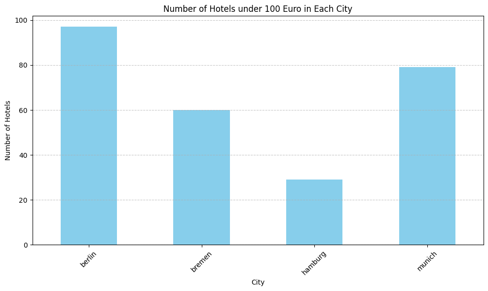

```python
# Plot the histogram
plt.figure(figsize=(10, 6))
under_100_count_per_city.plot(kind='bar', color='skyblue')
plt.title('Number of Hotels under 100 Euro in Each City')
plt.xlabel('City')
plt.ylabel('Number of Hotels')
plt.xticks(rotation=45)
plt.grid(axis='y', linestyle='--', alpha=0.7)
plt.tight_layout()
plt.show()
```

```python
def recommend_hotels(budget):
    if budget <= 1000:
        # Filter tours in the low price category
        low_price_hotels = combined_hotel[combined_hotel['price'] <= 100]

        # Get top 5 tours with the highest score in the low price category
        top_low_price_tours = low_price_hotels.nlargest(5, 'score')

        return top_low_price_tours

    elif 1000 < budget <= 10000:
        # Filter tours in the moderate price category
        moderate_price_hotels = combined_hotel[(combined_hotel['price'] > 100) & (all_tours['price'] <= 300)]

        # Get top 5 tours with the highest score in the moderate price category
        top_moderate_price_tours = moderate_price_hotels.nlargest(5, 'score')

        return top_moderate_price_tours

    else:
        # Filter tours in the high price category
        high_price_hotels = combined_hotel[combined_hotel['price'] > 300]

        # Get top 5 tours with the highest score in the high price category
        top_high_price_tours = high_price_hotels.nlargest(5, 'score')

        return top_high_price_tours
```

```python
# Example usage
budget = 1500  # User's budget in dollars
top_hotels = recommend_hotels(budget)

print("Top 5 Tours based on Budget:")
top_hotels.head()
```

```
Top 5 Tours based on Budget:
```

|  | website | name | location | distance | score | reviews | type | type2 | day | price | city |
| --- | --- | --- | --- | --- | --- | --- | --- | --- | --- | --- | --- |
| 695 | https://www.booking.com/hotel/de/top-floor-pen... | Top floor Penthouse with Garden | Friedrichshain-Kreuzberg, Berlin | 3.1 km from centre | 10.0 | 1.0 | One-Bedroom Apartment | 1 double bed | 1 night, 1 adult | 205.0 | munich |
| 741 | https://www.booking.com/hotel/de/3-personen-ap... | 3 Personen Apartment im Zentrum | Friedrichshain-Kreuzberg, Berlin | 4.1 km from centre | 10.0 | 4.0 | One-Bedroom Apartment | 1 double bed | 1 night, 1 adult | 243.0 | munich |
| 789 | https://www.booking.com/hotel/de/imagination-i... | Imagination in the Heart of the city | Mitte, Berlin | 2.7 km from centre | 10.0 | 1.0 | One-Bedroom Apartment | 1 double bed | 1 night, 1 adult | 153.0 | munich |
| 928 | https://www.booking.com/hotel/de/dream-cuddle-... | Dream cuddle Nest | Pankow, Berlin | 5.1 km from centre | 10.0 | 1.0 | One-Bedroom Apartment | 1 double bed | 1 night, 1 adult | 306.0 | munich |
| 1044 | https://www.booking.com/hotel/de/stay-house.en... | Ferienhaus mit Privatparkplatz, Terrasse und K... | Hemelingen, Bremen | 6.2 km from centre | 10.0 | 2.0 | Holiday Home | 5 beds (4 singles, 1 extra-large double) | 1 night, 1 adult | 259.0 | bremen |

## Step 6: Data Exploration

- Decide on data storage method (CSV files, databases like SQLite or PostgreSQL).

### must see

```python
germany_df.head()
```

|  | website1 | website2 | name | location | description | type | city |
| --- | --- | --- | --- | --- | --- | --- | --- |
| 0 | https://lonelyplanetstatic.imgix.net/marketing... | https://www.lonelyplanet.com/germany/lower-sax... | Herrenhäuser Gärten | Hanover | Proof that Hanover is not all buttoned-down bu... | must_see | Lower Saxony & Bremen |
| 1 | https://lp-cms-production.imgix.net/2019-06/2a... | https://www.lonelyplanet.com/germany/bergen-be... | Gedenkstätte Bergen-Belsen | Lower Saxony & Bremen | The Nazi-built camp at Bergen-Belsen began its... | must_see | Lower Saxony & Bremen |
| 2 | https://lonelyplanetstatic.imgix.net/marketing... | https://www.lonelyplanet.com/germany/lower-sax... | Schloss Marienburg | Lower Saxony & Bremen | Perched grandly above the Leine River, the neo... | must_see | Lower Saxony & Bremen |
| 3 | https://lonelyplanetstatic.imgix.net/marketing... | https://www.lonelyplanet.com/germany/bremen-ci... | Denkort Bunker Valentin | Bremen City | In 1943, the Nazis started construction of a m... | must_see | Lower Saxony & Bremen |
| 4 | https://lonelyplanetstatic.imgix.net/marketing... | https://www.lonelyplanet.com/germany/lower-sax... | Autostadt | Lower Saxony & Bremen | A hit with car buffs of all ages, Autostadt is... | must_see | Lower Saxony & Bremen |

Summary Statistics: Obtain summary statistics to understand the data better.

This will give us an overview of the numerical and categorical columns in the dataset.

```python
# Summary statistics
summary_stats = germany_df.describe(include='all')
summary_stats
```

|  | website1 | website2 | name | location | description | type | city |
| --- | --- | --- | --- | --- | --- | --- | --- |
| count | 1771 | 1771 | 1771 | 1771 | 1771 | 1771 | 1771 |
| unique | 691 | 1770 | 1736 | 18 | 1768 | 6 | 4 |
| top | https://lonelyplanetstatic.imgix.net/marketing... | https://www.lonelyplanet.com/germany/hamburg/s... | DJH Hostel | Munich | It took a vociferous grass-roots campaign to s... | must_see | Berlin |
| freq | 402 | 2 | 6 | 259 | 2 | 505 | 927 |

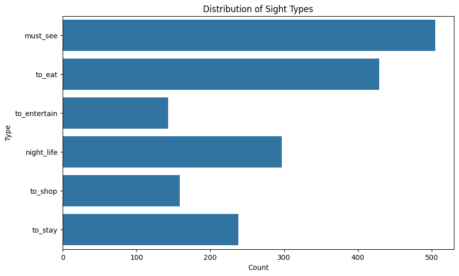

```python
import matplotlib.pyplot as plt
import seaborn as sns

# Visualizing the distribution of 'type'
plt.figure(figsize=(10, 6))
sns.countplot(data=germany_df, y='type')
plt.title('Distribution of Sight Types')
plt.xlabel('Count')
plt.ylabel('Type')
plt.show()
```

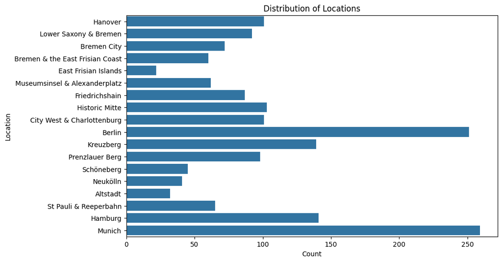

```python
# Visualizing the distribution of 'location'
plt.figure(figsize=(10, 6))
sns.countplot(data=germany_df, y='location')
plt.title('Distribution of Locations')
plt.xlabel('Count')
plt.ylabel('Location')
plt.show()
```

```python
top_sights = germany_df.sort_values(by='description', ascending=False).head(10)
top_sights
```

|  | website1 | website2 | name | location | description | type | city |
| --- | --- | --- | --- | --- | --- | --- | --- |
| 1279 | https://lonelyplanetstatic.imgix.net/marketing... | https://www.lonelyplanet.com/germany/hamburg/n... | St Michaelis Kirche | Hamburg | ‘Der Michel’, as it is affectionately called, ... | must_see | Hamburg |
| 689 | https://lonelyplanetstatic.imgix.net/marketing... | https://www.lonelyplanet.com/germany/berlin/hi... | Nobelhart & Schmutzig | Historic Mitte | ‘Brutally local’ is the motto at the Michelin-... | to_eat | Berlin |
| 1233 | https://www.lonelyplanet.com/germany/berlin/kr... | https://www.lonelyplanet.com/germany/berlin/kr... | Hotel Sarotti-Höfe | Kreuzberg | You’ll have sweet dreams in this 19th-century ... | to_stay | Berlin |
| 684 | https://lonelyplanetstatic.imgix.net/marketing... | https://www.lonelyplanet.com/germany/berlin/re... | Taverna Ousia | Berlin | You’ll be as exuberant as Zorba at this easy g... | to_eat | Berlin |
| 1591 | https://lonelyplanetstatic.imgix.net/marketing... | https://www.lonelyplanet.com/germany/munich/ny... | Rock Museum | Munich | Your lift ticket to the Olympiaturm also buys ... | must_see | Munich |
| 737 | https://lonelyplanetstatic.imgix.net/marketing... | https://www.lonelyplanet.com/germany/berline/m... | The Brooklyn | Museumsinsel & Alexanderplatz | You'll have a fine time giving your credit car... | to_eat | Berlin |
| 1727 | https://lonelyplanetstatic.imgix.net/marketing... | https://www.lonelyplanet.com/germany/munich/sc... | Words’ Worth Books | Munich | You'll find tonnes of English-language books, ... | to_shop | Munich |
| 275 | https://www.lonelyplanet.com/germany/bremen-ci... | https://www.lonelyplanet.com/germany/bremen-ci... | Bürstenhaus Carl Töddensen | Bremen City | You might find yourself pulled in by the lush ... | to_shop | Lower Saxony & Bremen |
| 152 | https://www.lonelyplanet.com/germany/bremerhav... | https://www.lonelyplanet.com/germany/bremerhav... | Olympisches Feuer | Bremen & the East Frisian Coast | You may find yourself surprised by the quality... | to_eat | Lower Saxony & Bremen |
| 1433 | https://lonelyplanetstatic.imgix.net/marketing... | https://www.lonelyplanet.com/germany/hamburg/s... | Cafe Geyer | St Pauli & Reeperbahn | You could come here for the breakfast, or the ... | night_life | Hamburg |

```python
popular_by_location = germany_df['location'].value_counts().head(5)
print(popular_by_location)
```

```
location
Munich            259
Berlin            251
Hamburg           141
Kreuzberg         139
Historic Mitte    103
Name: count, dtype: int64
```

### Tours

```python
all_tours.head()
```

|  | website | name | score | reviews | type | duration | comment1 | price | group | city | price_category |
| --- | --- | --- | --- | --- | --- | --- | --- | --- | --- | --- | --- |
| 0 | https://www.tripadvisor.com/AttractionProductR... | The Local Tour of Hamburg Historic Centre | 5.0 | 784.0 | Historical Tours | 2 hours | Pay-What-You-Want tour with booking fee!\n\nWi... | 3.0 | per adult | hamburg | Low |
| 1 | https://www.tripadvisor.com/AttractionProductR... | Private Small-Group Hamburg City Tour with a L... | 5.0 | 178.0 | Historical Tours | 3 hours | Welcome to our beloved Hamburg.\nI´m a former ... | 264.0 | per group | hamburg | Moderate |
| 2 | https://www.tripadvisor.com/AttractionProductR... | Hop-on hop-off on the water with the Maritime ... | 4.0 | 63.0 | Day Cruises | 1–2 hours | A sightseeing harbor cruise with the Maritime ... | 22.0 | per adult | hamburg | Low |
| 3 | https://www.tripadvisor.com/AttractionProductR... | Hamburg Dungeon Admission Ticket | 4.0 | 187.0 | Historical Tours | 1–2 hours | Experience 600 years of dark history - if you ... | 31.0 | per adult | hamburg | Low |
| 4 | https://www.tripadvisor.com/AttractionProductR... | Hamburg 2-hour harbor tour on the beautiful Elbe | 3.5 | 21.0 | Historical Tours | 2 hours | We offer an extensive Hamburg XXL harbor tour ... | 38.0 | per adult | hamburg | Low |

```python
# Summary statistics
summary_stats_tours = all_tours.describe(include='all')
summary_stats_tours
```

|  | website | name | score | reviews | type | duration | comment1 | price | group | city | price_category |
| --- | --- | --- | --- | --- | --- | --- | --- | --- | --- | --- | --- |
| count | 1682 | 1682 | 771.000000 | 764.000000 | 1682 | 1682 | 1672 | 1675.000000 | 1682 | 1682 | 1682 |
| unique | 1571 | 1550 | NaN | NaN | 69 | 104 | 1403 | NaN | 2 | 4 | 3 |
| top | https://www.tripadvisor.com/AttractionProductR... | Hop-on Hop-off Tour : combined City Tour by Bu... | NaN | NaN | Historical Tours | 2 hours | Why spend your precious time waiting in long s... | NaN | per adult | berlin | Moderate |
| freq | 3 | 4 | NaN | NaN | 713 | 229 | 17 | NaN | 1309 | 729 | 788 |
| mean | NaN | NaN | 4.646563 | 39.086387 | NaN | NaN | NaN | 336.671642 | NaN | NaN | NaN |
| std | NaN | NaN | 0.704290 | 103.336300 | NaN | NaN | NaN | 539.378052 | NaN | NaN | NaN |
| min | NaN | NaN | 1.000000 | 1.000000 | NaN | NaN | NaN | 3.000000 | NaN | NaN | NaN |
| 25% | NaN | NaN | 4.500000 | 2.000000 | NaN | NaN | NaN | 70.500000 | NaN | NaN | NaN |
| 50% | NaN | NaN | 5.000000 | 5.000000 | NaN | NaN | NaN | 187.000000 | NaN | NaN | NaN |
| 75% | NaN | NaN | 5.000000 | 26.000000 | NaN | NaN | NaN | 381.500000 | NaN | NaN | NaN |
| max | NaN | NaN | 5.000000 | 931.000000 | NaN | NaN | NaN | 7633.000000 | NaN | NaN | NaN |

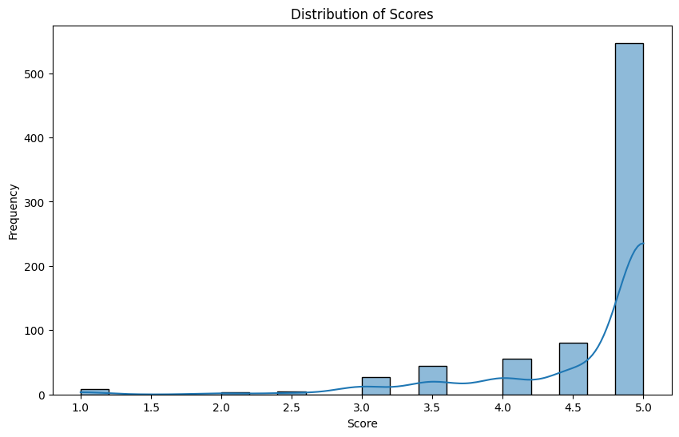

```python
# Visualizing the distribution of scores
plt.figure(figsize=(10, 6))
sns.histplot(all_tours['score'], bins=20, kde=True)
plt.title('Distribution of Scores')
plt.xlabel('Score')
plt.ylabel('Frequency')
plt.show()
```

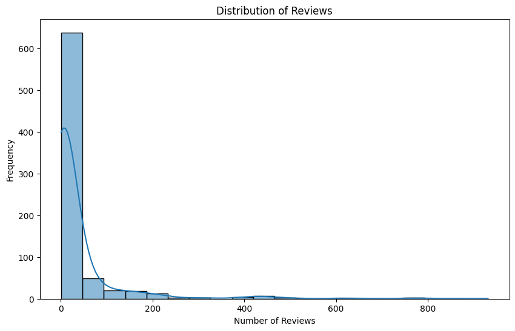

```python
# Visualizing the distribution of reviews
plt.figure(figsize=(10, 6))
sns.histplot(all_tours['reviews'], bins=20, kde=True)
plt.title('Distribution of Reviews')
plt.xlabel('Number of Reviews')
plt.ylabel('Frequency')
plt.show()
```

```python
top_rated_tours = all_tours.sort_values(by='score', ascending=False).head(10)
print(top_rated_tours)
```

```
                                                website  \
0     https://www.tripadvisor.com/AttractionProductR...
495   https://www.tripadvisor.com/AttractionProductR...
1020  https://www.tripadvisor.com/AttractionProductR...
1023  https://www.tripadvisor.com/AttractionProductR...
1027  https://www.tripadvisor.com/AttractionProductR...
1028  https://www.tripadvisor.com/AttractionProductR...
1030  https://www.tripadvisor.com/AttractionProductR...
1031  https://www.tripadvisor.com/AttractionProductR...
1036  https://www.tripadvisor.com/AttractionProductR...
1037  https://www.tripadvisor.com/AttractionProductR...

                                                   name  score  reviews  \
0             The Local Tour of Hamburg Historic Centre    5.0    784.0
495   Berlin By Night by Private Minivan Highlights ...    5.0      2.0
```

[output cut: 44 more lines]

```python
# Aggregate statistics by city
city_stats = all_tours.groupby('city').agg({'score': 'mean', 'reviews': 'mean'})
print(city_stats)
```

```
            score    reviews
city
berlin   4.724377  42.407821
bremen   4.328125  62.125000
hamburg  4.234375  32.052083
munich   4.723404  34.586331
```

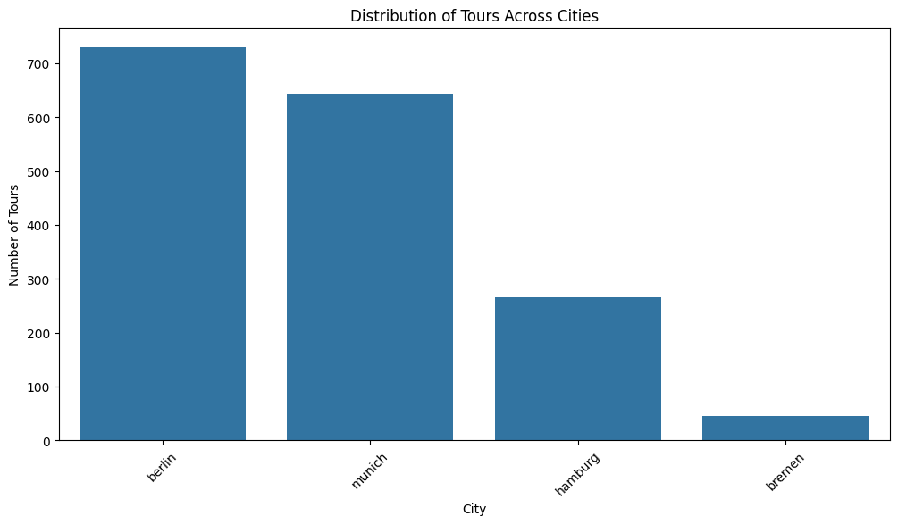

```python
# Visualizing the distribution of tours across cities
plt.figure(figsize=(12, 6))
sns.countplot(data=all_tours, x='city', order=all_tours['city'].value_counts().index)
plt.title('Distribution of Tours Across Cities')
plt.xlabel('City')
plt.ylabel('Number of Tours')
plt.xticks(rotation=45)
plt.show()
```

```python
# Compare top-rated tours for each city
top_rated_by_city = all_tours.loc[all_tours.groupby('city')['score'].idxmax()]

# Compare most reviewed tours for each city
most_reviewed_by_city = all_tours.loc[all_tours.groupby('city')['reviews'].idxmax()]

print("Top-rated tours by city:")
print(top_rated_by_city[['city', 'name', 'score']])

print("\nMost reviewed tours by city:")
print(most_reviewed_by_city[['city', 'name', 'reviews']])
```

```
Top-rated tours by city:
         city                                               name  score
266    berlin              Discover Berlin Half-Day Walking Tour    5.0
1002   bremen                           Bremen Schnoor Area Tour    5.0
0     hamburg          The Local Tour of Hamburg Historic Centre    5.0
1049   munich  Dachau Concentration Camp Memorial Site Tour f...    5.0

Most reviewed tours by city:
         city                                               name  reviews
295    berlin               Rude Bastards tour of Berlin (CYHIT)    931.0
1015   bremen          The Local Tour of Hamburg Historic Centre    784.0
0     hamburg          The Local Tour of Hamburg Historic Centre    784.0
1053   munich  Salzburg Sightseeing Day Trip from Munich by Rail    666.0
```

## Step 7: Build the Recommendation Engine

- Create a recommendation engine based on user preferences.
- Implement user input for preferences and calculate scores for destinations.

### City Recommender

```python
# Preprocess the text data
def preprocess_text(text):
    # Tokenize the text
    tokens = word_tokenize(text)
    # Remove punctuation and lowercase the tokens
    table = str.maketrans('', '', string.punctuation)
    tokens = [w.translate(table).lower() for w in tokens]
    # Remove stopwords
    stop_words = set(stopwords.words('english'))
    tokens = [word for word in tokens if word not in stop_words]
    # Join the tokens back into a string
    preprocessed_text = ' '.join(tokens)
    return preprocessed_text

# Apply preprocessing to the "description" column
filtered_df['preprocessed_description'] = filtered_df['description'].apply(preprocess_text)

# Initialize BERTopic model
topic_model = BERTopic()

# Fit the model on preprocessed descriptions
topics, _ = topic_model.fit_transform(filtered_df['preprocessed_description'])
filtered_df['topic'] = topics

# Print the topics and associated descriptions
print("Topics and Associated Descriptions:")
for topic_id in filtered_df['topic'].unique():
    topic_description = filtered_df[filtered_df['topic'] == topic_id]['description'].iloc[0]
    print(f"Topic {topic_id}: {topic_description}")
```

```
Topics and Associated Descriptions:
Topic -1: Proof that Hanover is not all buttoned-down business are the grandiose Baroque Royal Gardens of Herrenhausen, about 5km north of the city centre, which…
Topic 6: The Nazi-built camp at Bergen-Belsen began its existence in 1940 as a POW camp, but became a concentration camp after being taken over by the SS in 1943,…
Topic 8: Perched grandly above the Leine River, the neo-Gothic Schloss Marienburg (built from 1858–67) was a present from Hanover's King George V to his wife Marie…
Topic 2: For art lovers, the highlight of Bremen’s Kulturmeile (Cultural Mile) is the Kunsthalle, which presents a large permanent collection of paintings,…
Topic 10: The charming medieval coopers lane was transformed into a prime example of mostly expressionist architecture in the 1920s at the instigation of coffee…
Topic 4: This shiny, space-age museum offers a journey around the world along the longitudinal meridian 8° east, through climate zones in Switzerland, Italy, Niger…
Topic 12: Bremen has a strong aerospace industry, and space buffs will enjoy the eye-catching, oyster-shaped Universum Science Centre, where you can make virtual…
Topic 5: More than 640 hectares (almost twice the size of NYC's Central Park), Europe's largest city forest, Eilenriede, is also known as Hanover's grüne Lunge …
Topic 15: Hildesheim’s Unesco World Heritage–listed cathedral took its present form in 1061 and was virtually rebuilt after its WWII bombing, then reopened in 2014…
Topic 3: Designed and built by Bauhaus founder Walter Gropius in 1911, this factory, which has been producing shoe lasts for over 100 years, is regarded as the…
Topic 16: This maze of narrow, winding alleys was once the fishermen's quarter and later a red-light district. Now its doll's-house-sized cottages contain boutiques…
Topic 0: The football faithful will delight in this sports museum covering the history of the Werder Bremen team's past 100-plus years, with multimedia exhibits…
Topic 13: An aquarium, exhibits and short films at this national parks office explain more about the varieties of plant, bird and sea life that call the Wattenmeer …
Topic 1: One of the newest cocktail bars on the Hanover scene, sleek Bukowski's mixes leather couches with exposed brick walls and industrial-style stools. Spirits…
Topic 17: Set high atop a sand dune overlooking the sea on the western tip of the island, this octagonal 19th-century cafe has been redone on the inside with a…
Topic 14: A great place to pick up a cappuccino, latte or flat white, plus some cake or pastry to go with it. Lactose-free and non-dairy milks (soy etc) available,…
Topic 9: Buy gifts with a good conscience at this fair-trade shop featuring the work of craftspeople from around the world – India, Thailand, Colombia, Chile and…
Topic 7: For an insightful primer on the Berlin Wall, visit this outdoor memorial, which extends for 1.4km along Bernauer Strasse and integrates an original…
Topic 11: Germany's film history gets the star treatment at this engaging museum. Explore galleries dedicated to pioneers like Fritz Lang, ground-breaking movies…
```

```python
topic_model.get_topic_info()
```

|  | Topic | Count | Name | Representation | Representative_Docs |
| --- | --- | --- | --- | --- | --- |
| 0 | -1 | 405 | -1_berlin_one_museum_the | [berlin, one, museum, the, building, germany, ... | [former print shop nonprofit museum one large... |
| 1 | 0 | 216 | 0_music_theatre_club_dance | [music, theatre, club, dance, venue, concerts,... | [event venue part historic former wedding crem... |
| 2 | 1 | 82 | 1_bar_cocktail_wine_beer | [bar, cocktail, wine, beer, drinks, lit, loung... | [bar lounge mostly gets relaxed 20s early30s c... |
| 3 | 2 | 50 | 2_art_artist_artists_gallery | [art, artist, artists, gallery, contemporary, ... | [small elegant exhibition hall deutsche bank... |
| 4 | 3 | 44 | 3_women_fashion_label_men | [women, fashion, label, men, fashions, shop, s... | [berlinbased uvr label designs urban fashions ... |
| 5 | 4 | 42 | 4_museum_history_greek_lion | [museum, history, greek, lion, collection, mid... | [museum chronicles area ’ history middle ages ... |
| 6 | 5 | 36 | 5_garden_beer_park_munich | [garden, beer, park, munich, altstadt, botanic... | [munich verdant new botanical garden segues sm... |
| 7 | 6 | 32 | 6_memorial_nazi_victims_nazis | [memorial, nazi, victims, nazis, soviet, 1945,... | [heart treptower park gargantuan soviet war m... |
| 8 | 7 | 27 | 7_wall_berlin_east_war | [wall, berlin, east, war, border, cold, 1990, ... | [looks like postapocalyptic garden actually me... |
| 9 | 8 | 24 | 8_tower_rulers_church_built | [tower, rulers, church, built, lift, munich, g... | [1705 französischer dom built huguenot refuges... |
| 10 | 9 | 22 | 9_market_flea_handmade_store | [market, flea, handmade, store, souvenirs, bra... | [join throngs thrifty trinket hunters blearye... |
| 11 | 10 | 20 | 10_coffee_cafe_cakes_roasted | [coffee, cafe, cakes, roasted, beans, java, fr... | [pioneers thirdwave coffee berlin yumi kiduk ... |
| 12 | 11 | 20 | 11_cinema_movies_arthouse_films | [cinema, movies, arthouse, films, indie, scree... | [beloved openair cinema screens international ... |
| 13 | 12 | 17 | 12_maritime_ship_sea_harbour | [maritime, ship, sea, harbour, bremen, ships, ... | [blueandwhite squarepatterned floor matching d... |
| 14 | 13 | 17 | 13_zoo_kids_enclosures_animals | [zoo, kids, enclosures, animals, educational, ... | [zoo meer ’ spectacular face things enthrals ... |
| 15 | 14 | 15 | 14_chocolate_fresh_exotic_gourmet | [chocolate, fresh, exotic, gourmet, pick, glob... | [fresh fruit vegetables piles artisanal chees... |
| 16 | 15 | 12 | 15_wwii_bombing_reconstructed_church | [wwii, bombing, reconstructed, church, 1943, r... | [built illegally wwii russian hermit called fa... |
| 17 | 16 | 12 | 16_stalls_saturday_wednesday_market | [stalls, saturday, wednesday, market, leafy, s... | [wednesday saturday morning luck hohum winter... |
| 18 | 17 | 11 | 17_island_sky_sand_overlooking | [island, sky, sand, overlooking, hotel, views,... | [soak rays grand city views colourful cocktai... |

```python
topic_model.visualize_topics()
```

[output not shown]

```python
# Merge topics with the original dataframe
merged_df = pd.merge(filtered_df, filtered_df.groupby('location')['topic'].apply(list).reset_index(name='topics'), on='location')

# Group by city and aggregate the topics
city_topics = merged_df.groupby('location')['topics'].agg(lambda x: [item for sublist in x for item in sublist]).reset_index()

# Print cities and their associated topics
print("Cities and Associated Topics:")
for index, row in city_topics.iterrows():
    print(f"{row['location']}: {row['topics']}")
```

```
Cities and Associated Topics:
Altstadt: [8, 2, -1, 7, -1, 14, -1, 2, 0, -1, 5, -1, 1, 0, 9, -1, 0, -1, 8, 2, -1, 7, -1, 14, -1, 2, 0, -1, 5, -1, 1, 0, 9, -1, 0, -1, 8, 2, -1, 7, -1, 14, -1, 2, 0, -1, 5, -1, 1, 0, 9, -1, 0, -1, 8, 2, -1, 7, -1, 14, -1, 2, 0, -1, 5, -1, 1, 0, 9, -1, 0, -1, 8, 2, -1, 7, -1, 14, -1, 2, 0, -1, 5, -1,…
Berlin: [2, 6, -1, 8, 2, -1, -1, 13, 5, -1, 8, -1, -1, 11, 4, -1, 8, 6, 4, 6, 13, -1, -1, -1, -1, -1, -1, 5, 2, -1, 6, 6, -1, -1, 0, 13, -1, -1, 0, -1, -1, 5, 6, 6, -1, -1, 8, 2, -1, 0, 7, -1, 4, 7, 8, 0, 6, 6, -1, -1, 7, 7, 3, 13, 6, 7, 7, -1, -1, 8, -1, -1, -1, 2, -1, 0, 11, 11, 0, 11, 0, 0, 11, 0…
Bremen & the East Frisian Coast: [-1, 2, 4, 8, 4, -1, 4, 2, 12, 2, 2, 6, 5, 2, -1, 2, 4, -1, 2, 4, 2, 12, -1, 13, -1, 12, 0, -1, 1, 1, 10, 1, 3, -1, 2, 4, 8, 4, -1, 4, 2, 12, 2, 2, 6, 5, 2, -1, 2, 4, -1, 2, 4, 2, 12, -1, 13, -1, 12, 0, -1, 1, 1, 10, 1, 3, -1, 2, 4, 8, 4, -1, 4, 2, 12, 2, 2, 6, 5, 2,…
Bremen City: [6, 2, 10, 12, 8, -1, 2, 4, 16, -1, -1, 12, -1, -1, 4, -1, -1, 12, 0, 5, 0, 0, 0, 0, 0, 0, 1, -1, 1, 0, 0, 10, 0, 17, 0, -1, -1, -1, -1, 14, -1, 14, 9, 6, 2, 10, 12, 8, -1, 2, 4, 16, -1, -1, 12, -1, -1, 4, -1, -1, 12, 0, 5, 0, 0, 0, 0, 0, 0, 1, -1, 1, 0, 0, 10, 0, 17, 0, -1, -1, -1, -1,…
City West & Charlottenburg: [-1, 13, -1, -1, -1, 4, 5, 15, -1, 2, 2, 4, -1, -1, 13, 2, 5, -1, -1, -1, 2, 6, 2, -1, 3, 0, 0, 0, 11, 0, 11, 0, 0, 0, -1, -1, -1, 1, -1, -1, 2, 3, -1, 14, -1, 3, -1, -1, 9, -1, -1, 13, -1, -1, -1, 4, 5, 15, -1, 2, 2, 4, -1, -1, 13, 2, 5, -1, -1, -1, 2, 6, 2, -1, 3, 0, 0,…
East Frisian Islands: [4, -1, 13, 12, -1, -1, 13, 12, -1, -1, 12, 1, 17, 1, 17, 4, -1, 13, 12, -1, -1, 13, 12, -1, -1, 12, 1, 17, 1, 17, 4, -1, 13, 12, -1, -1, 13, 12, -1, -1, 12, 1, 17, 1, 17, 4, -1, 13, 12, -1, -1, 13, 12, -1, -1, 12, 1, 17, 1, 17, 4, -1, 13, 12, -1, -1, 13, 12, -1, -1, 12, 1, 17,…
Friedrichshain: [-1, -1, -1, 7, 4, -1, -1, 2, -1, -1, -1, -1, 6, 6, 7, -1, -1, 0, -1, -1, -1, 11, 11, 11, 0, 0, 1, 0, -1, 1, -1, -1, 0, 0, 1, 0, 0, -1, -1, -1, 0, 0, -1, 0, 0, -1, 1, 1, 0, -1, 9, 9, 14, 3, -1, -1, -1, 3, 3, -1, -1, -1, -1, 7, 4, -1, -1, 2, -1, -1, -1, -1, 6, 6, 7, -1, -1, 0, -1, -1,…
Hamburg: [-1, 8, -1, -1, -1, 12, 6, 12, 2, -1, -1, -1, -1, 0, -1, 12, -1, 0, 16, 7, 12, 13, 2, -1, 12, -1, -1, 16, 2, 1, -1, 0, 0, 0, 0, 11, 0, 0, 0, 0, -1, 0, 0, 1, -1, -1, 16, 1, -1, 0, 1, -1, 1, 10, 0, 1, 2, 9, 14, 9, 0, 9, -1, -1, 1, 1, 0, 3, 9, 12, -1, 9, -1, -1, 8, -1, -1, -1, 12, 6, 12, 2, -1…
Hanover: [-1, -1, -1, -1, 5, 5, 2, 15, -1, 8, -1, 15, 2, -1, 4, 4, 4, -1, 13, 0, -1, -1, 8, 0, 0, 0, 0, -1, -1, -1, 0, 0, 0, 0, 0, 0, 0, 0, 0, 1, 12, 5, -1, 1, -1, 0, 1, 1, 10, 0, -1, 0, 0, -1, 0, 0, 0, 9, -1, 16, 9, -1, -1, -1, -1, -1, 5, 5, 2, 15, -1, 8, -1, 15, 2, -1, 4, 4, 4, -1, 13, 0, -1, -1, …
Historic Mitte: [6, 15, -1, 15, 7, 8, 7, -1, 7, 7, -1, 6, 0, 2, -1, 0, -1, -1, -1, -1, -1, -1, -1, 8, 8, -1, 6, -1, -1, 7, -1, 6, -1, -1, -1, 7, -1, 7, -1, -1, 6, 7, -1, 6, -1, -1, -1, 6, -1, 7, -1, 2, 0, 0, 0, 11, 0, 0, 0, 0, 0, 0, 17, 0, 7, -1, -1, 14, 3, 14, 9, -1, 9, 3, -1, 6, 15, -1, 15, 7, 8, …
Kreuzberg: [-1, -1, -1, 4, 7, -1, 17, 2, 0, 5, -1, -1, -1, -1, -1, -1, -1, 2, -1, 2, 2, 2, 2, 2, 7, 0, 11, 0, 0, 0, 0, 0, -1, 0, 0, 0, 0, 0, 0, -1, 0, 0, 1, 0, -1, -1, -1, 0, 0, -1, 1, 1, 3, -1, -1, -1, 1, 1, -1, 0, -1, -1, 0, 0, 0, 1, 17, 1, 0, 1, -1, 0, -1, -1, 1, 0, 3, -1, 0, 3, -1, -1, 3, -1, 3,…
Lower Saxony & Bremen: [6, 8, -1, -1, 4, -1, 2, -1, 15, -1, 3, 15, 15, 4, -1, 4, -1, -1, -1, 4, 15, -1, -1, 5, -1, -1, -1, 4, 2, 6, -1, -1, 5, 0, 0, 1, 1, 1, 0, 0, 10, 0, 0, 0, 14, 1, 10, -1, 3, -1, 3, -1, -1, 6, 8, -1, -1, 4, -1, 2, -1, 15, -1, 3, 15, 15, 4, -1, 4, -1, -1, -1, 4, 15, -1, -1, 5, -1,…
Munich: [5, 8, -1, 5, -1, 4, -1, -1, -1, 4, -1, -1, -1, 0, 8, 0, 4, 8, 0, -1, 6, -1, 8, 5, 11, -1, -1, -1, -1, -1, 14, 4, -1, -1, 15, -1, -1, 15, 4, -1, 4, 8, 4, -1, 13, -1, 2, 6, 4, -1, 5, 13, 4, -1, 0, -1, -1, 0, -1, 5, -1, 5, 5, -1, -1, 6, -1, -1, -1, -1, 5, -1, -1, -1, 8, -1, 13, -1, -1, 0, -1, …
Museumsinsel & Alexanderplatz: [4, -1, -1, -1, -1, 4, 4, 4, 4, -1, 17, 4, -1, -1, -1, 2, -1, 13, 1, 6, -1, 7, -1, 1, -1, 4, -1, -1, 0, 0, -1, -1, -1, 0, -1, -1, 3, 3, -1, 3, -1, 4, -1, -1, -1, -1, 4, 4, 4, 4, -1, 17, 4, -1, -1, -1, 2, -1, 13, 1, 6, -1, 7, -1, 1, -1, 4, -1, -1, 0, 0, -1, -1, -1, 0, -…
Neukölln: [1, -1, 5, -1, -1, 0, 0, 11, 0, -1, 5, -1, 1, -1, 0, 1, 1, -1, 0, -1, 1, 0, 14, 10, 2, 9, 1, -1, 5, -1, -1, 0, 0, 11, 0, -1, 5, -1, 1, -1, 0, 1, 1, -1, 0, -1, 1, 0, 14, 10, 2, 9, 1, -1, 5, -1, -1, 0, 0, 11, 0, -1, 5, -1, 1, -1, 0, 1, 1, -1, 0, -1, 1, 0, 14, 10, 2, 9, 1, -1, 5, -1, -1, 0, 0…
Prenzlauer Berg: [7, -1, 5, -1, 1, -1, -1, 6, -1, 1, 7, 13, 0, 0, -1, 0, 0, -1, 1, 1, 1, 1, 1, 5, 1, 1, 10, -1, 17, -1, 1, -1, -1, 10, -1, -1, 0, 1, 10, 9, 16, 16, 14, -1, 13, -1, 3, 9, -1, 3, 3, 7, -1, 5, -1, 1, -1, -1, 6, -1, 1, 7, 13, 0, 0, -1, 0, 0, -1, 1, 1, 1, 1, 1, 5, 1, 1, 10, -1, 17, -1, 1,…
Schöneberg: [-1, -1, 2, -1, 6, -1, -1, -1, 6, 7, 0, -1, 1, -1, 1, 0, 11, 1, -1, 1, 17, 10, 2, -1, 16, 9, -1, 3, 14, 3, 3, 14, -1, -1, 2, -1, 6, -1, -1, -1, 6, 7, 0, -1, 1, -1, 1, 0, 11, 1, -1, 1, 17, 10, 2, -1, 16, 9, -1, 3, 14, 3, 3, 14, -1, -1, 2, -1, 6, -1, -1, -1, 6, 7, 0, -1, 1, -1, 1, 0, 11, 1…
St Pauli & Reeperbahn: [16, 16, -1, -1, 7, -1, -1, 15, -1, -1, 1, 0, 12, 0, 0, 0, 0, 0, 0, 0, -1, -1, 0, -1, -1, 10, -1, 0, 0, 0, 0, 0, -1, -1, 0, 0, 0, 0, 17, -1, 17, -1, -1, 9, 3, 16, 16, -1, -1, 7, -1, -1, 15, -1, -1, 1, 0, 12, 0, 0, 0, 0, 0, 0, 0, -1, -1, 0, -1, -1, 10, -1, 0, 0, 0, 0, 0, -1, -1…
```

```python
# Now let's visualize these cities and their associated topics on a scatterplot
import plotly.express as px

# Create a DataFrame for the scatterplot
scatter_df = pd.DataFrame({
    'location': city_topics['location'],
    'Topic': city_topics['topics']
})

# Reshape the DataFrame so that each topic gets its own row
scatter_df = scatter_df.explode('Topic').reset_index(drop=True)

# Create the scatterplot
fig = px.scatter(scatter_df, x='location', y='Topic', color='Topic',
                 title='Cities and Associated Topics',
                 labels={'Citlocationy': 'location', 'Topic': 'Topic'},
                 width=800, height=600)

# Update layout for better visualization
fig.update_traces(marker=dict(size=12, opacity=0.8),
                  selector=dict(mode='markers'))

# Show the plot
fig.show()
```

[output not shown]

```python
scatter_df.head(2000)
```

|  | location | Topic |
| --- | --- | --- |
| 0 | Altstadt | 8 |
| 1 | Altstadt | 2 |
| 2 | Altstadt | -1 |
| 3 | Altstadt | 7 |
| 4 | Altstadt | -1 |
| ... | ... | ... |
| 1995 | Berlin | 6 |
| 1996 | Berlin | -1 |
| 1997 | Berlin | -1 |
| 1998 | Berlin | 0 |
| 1999 | Berlin | 13 |

2000 rows × 2 columns

```python
# Filter the DataFrame for Topic 3
topic_3_cities = scatter_df[scatter_df['Topic'] == 3]

# Count the occurrences of each city for Topic 3
city_counts = topic_3_cities['location'].value_counts()

# Get the city with the highest count
most_common_city = city_counts.idxmax()
count_of_most_common_city = city_counts.max()

print(f"The most relevant city for Topic 3 is {most_common_city} with a count of {count_of_most_common_city}.")
```

```
The most relevant city for Topic 3 is Berlin with a count of 1804.
```

```python
for topic_num in range(-1, 19):
    # Filter the DataFrame for the current topic
    topic_cities = scatter_df[scatter_df['Topic'] == topic_num]

    # Check if there are any entries for this topic
    if not topic_cities.empty:
        # Count the occurrences of each city for the current topic
        city_counts = topic_cities['location'].value_counts()

        # Get the city with the highest count
        most_common_city = city_counts.idxmax()
        count_of_most_common_city = city_counts.max()

        print(f"The most relevant city for Topic {topic_num} is {most_common_city} with a count of {count_of_most_common_city}.")
    else:
        print(f"No data for Topic {topic_num}.")
```

```
The most relevant city for Topic -1 is Munich with a count of 11696.
The most relevant city for Topic 0 is Munich with a count of 6192.
The most relevant city for Topic 1 is Berlin with a count of 2460.
The most relevant city for Topic 2 is Berlin with a count of 1312.
The most relevant city for Topic 3 is Berlin with a count of 1804.
The most relevant city for Topic 4 is Munich with a count of 2064.
The most relevant city for Topic 5 is Munich with a count of 3096.
The most relevant city for Topic 6 is Berlin with a count of 1640.
The most relevant city for Topic 7 is Berlin with a count of 984.
The most relevant city for Topic 8 is Munich with a count of 1376.
The most relevant city for Topic 9 is Munich with a count of 516.
The most relevant city for Topic 10 is Berlin with a count of 656.
The most relevant city for Topic 11 is Berlin with a count of 1148.
The most relevant city for Topic 12 is Hamburg with a count of 438.
The most relevant city for Topic 13 is Berlin with a count of 656.
The most relevant city for Topic 14 is Munich with a count of 172.
The most relevant city for Topic 15 is Munich with a count of 344.
The most relevant city for Topic 16 is Hamburg with a count of 219.
The most relevant city for Topic 17 is Kreuzberg with a count of 182.
No data for Topic 18.
```

### Tour Recommender

```python
def recommend_tours(budget):
    if budget <= 1000:
        # Filter tours in the low price category
        low_price_tours = all_tours[all_tours['price'] <= 50]

        # Get top 5 tours with the highest score in the low price category
        top_low_price_tours = low_price_tours.nlargest(5, 'score')

        return top_low_price_tours

    elif 1000 < budget <= 10000:
        # Filter tours in the moderate price category
        moderate_price_tours = all_tours[(all_tours['price'] > 50) & (all_tours['price'] <= 300)]

        # Get top 5 tours with the highest score in the moderate price category
        top_moderate_price_tours = moderate_price_tours.nlargest(5, 'score')

        return top_moderate_price_tours

    else:
        # Filter tours in the high price category
        high_price_tours = all_tours[all_tours['price'] > 10000]

        # Get top 5 tours with the highest score in the high price category
        top_high_price_tours = high_price_tours.nlargest(5, 'score')

        return top_high_price_tours
```

```python
# Example usage
budget = 200  # User's budget in dollars
top_tours = recommend_tours(budget)

print("Top 5 Tours based on Budget:")
top_tours.head()
```

```
Top 5 Tours based on Budget:
```

|  | website | name | score | reviews | type | duration | comment1 | price | group | city | price_category |
| --- | --- | --- | --- | --- | --- | --- | --- | --- | --- | --- | --- |
| 0 | https://www.tripadvisor.com/AttractionProductR... | The Local Tour of Hamburg Historic Centre | 5.0 | 784.0 | Historical Tours | 2 hours | Pay-What-You-Want tour with booking fee!\n\nWi... | 3.0 | per adult | hamburg | Low |
| 5 | https://www.tripadvisor.com/AttractionProductR... | Treasure Hunt through Hamburgs HafenCity | 5.0 | 163.0 | Fun & Games | 2–3 hours | A unique connection between solving riddles an... | 22.0 | per adult | hamburg | Low |
| 14 | https://www.tripadvisor.com/AttractionProductR... | Guided Hamburg City Bike Tour | 5.0 | 438.0 | Bike Tours | 3–4 hours | This sightseeing bike tour is the perfect way ... | 40.0 | per adult | hamburg | Low |
| 15 | https://www.tripadvisor.com/AttractionProductR... | Sailing trip on the Hamburg Outer Alster | 5.0 | 20.0 | Adventure Tours | 1–2 hours | What an experience! Together with other sailor... | 39.0 | per adult | hamburg | Low |
| 18 | https://www.tripadvisor.com/AttractionProductR... | "Highlights of Hamburg" Biketour | 5.0 | 19.0 | City Tours | 3 hours | The most beautiful way to explore Hamburg\n\nE... | 40.0 | per adult | hamburg | Low |

### Activites Recomendation

```python
filtered_df.head()
```

[output not shown]

```python
# Assuming the most relevant city for Topic 3 is "Altstadt"
most_common_city = "Munich"

# Filter the DataFrame for the most relevant city
city_df = filtered_df[filtered_df['location'] == most_common_city]
```

```python
# Sort the rows based on their relevance to Topic 3
topic_3_sorted = city_df[city_df['topic'] == 4].sort_values(by='topic', ascending=False)

# Get the top 5 things to do in the city for Topic 3
top_5_things_to_do = topic_3_sorted.head(5)[['website1', 'name', 'location', 'description', 'type', 'city']]
```

```python
print(f"The best 5 things to do in {most_common_city} for Topic 3 are:")
top_5_things_to_do.head()
```

[output not shown]

|  | website1 | name | location | description | type | city |
| --- | --- | --- | --- | --- | --- | --- |
| 1653 | https://www.lonelyplanet.com/germany/munich/al... | Bayerische Staatsoper | Munich | One of the world's best opera companies, the B... | to_entertain | Munich |
| 1654 | https://www.lonelyplanet.com/germany/munich/al... | Bayerisches Staatsschauspiel | Munich | This leading ensemble has gone alternative in ... | to_entertain | Munich |
| 1655 | https://www.lonelyplanet.com/germany/munich/al... | Münchner Kammerspiele | Munich | A venerable theatre with an edgy bent, the Kam... | to_entertain | Munich |
| 1663 | https://www.lonelyplanet.com/germany/munich/ma... | Münchner Theater für Kinder | Munich | At the Münchner Theater für Kinder budding the... | to_entertain | Munich |
| 1664 | https://www.lonelyplanet.com/germany/munich/al... | Staatstheater am Gärtnerplatz | Munich | Spruced up to southern German standards for it... | to_entertain | Munich |

### Restaurant Recommendation

```python
filtered_rest_df = germany_df[germany_df['type'].isin(['to_eat'])]
```

```python
filtered_rest_df.head()
```

|  | website1 | website2 | name | location | description | type | city |
| --- | --- | --- | --- | --- | --- | --- | --- |
| 115 | https://www.lonelyplanet.com/germany/lower-sax... | https://www.lonelyplanet.com/germany/lower-sax... | Al-Dar | Hanover | This popular Syrian restaurant a stone's throw... | to_eat | Lower Saxony & Bremen |
| 116 | https://www.lonelyplanet.com/germany/lower-sax... | https://www.lonelyplanet.com/germany/lower-sax... | Vietal Kitchen | Hanover | Pale-green louvres and bamboo lanterns set a F... | to_eat | Lower Saxony & Bremen |
| 117 | https://www.lonelyplanet.com/germany/hildeshei... | https://www.lonelyplanet.com/germany/hildeshei... | Schlegels Weinstuben | Lower Saxony & Bremen | The lopsided walls of this rose-covered, 500-y... | to_eat | Lower Saxony & Bremen |
| 118 | https://www.lonelyplanet.com/germany/norderney... | https://www.lonelyplanet.com/germany/norderney... | Seesteg | East Frisian Islands | Nordeney's Michelin-starred restaurant offers ... | to_eat | Lower Saxony & Bremen |
| 119 | https://www.lonelyplanet.com/germany/lower-sax... | https://www.lonelyplanet.com/germany/lower-sax... | Basil | Hanover | These former stables to the north of town now ... | to_eat | Lower Saxony & Bremen |

```python
# Preprocess the text data
def preprocess_text(text):
    # Tokenize the text
    tokens = word_tokenize(text)
    # Remove punctuation and lowercase the tokens
    table = str.maketrans('', '', string.punctuation)
    tokens = [w.translate(table).lower() for w in tokens]
    # Remove stopwords
    stop_words = set(stopwords.words('english'))
    tokens = [word for word in tokens if word not in stop_words]
    # Join the tokens back into a string
    preprocessed_text = ' '.join(tokens)
    return preprocessed_text

# Apply preprocessing to the "description" column
filtered_rest_df['preprocessed_description'] = filtered_rest_df['description'].apply(preprocess_text)

# Initialize BERTopic model
topic_model = BERTopic()

# Fit the model on preprocessed descriptions
topics, _ = topic_model.fit_transform(filtered_rest_df['preprocessed_description'])
filtered_rest_df['topic'] = topics
```

```python
# Print the topics and associated descriptions for filtered_df
print("Topics and Associated Descriptions for filtered_df:")
for topic_id in filtered_rest_df['topic'].unique():
    topic_description = filtered_rest_df[filtered_rest_df['topic'] == topic_id]['description'].iloc[0]
    print(f"Topic {topic_id}: {topic_description}")
```

```
Topics and Associated Descriptions for filtered_df:
Topic 0: This popular Syrian restaurant a stone's throw from the Hauptbahnhof features hushed, candlelit dining and attentive service within a pleasant, minimalist…
Topic 1: The lopsided walls of this rose-covered, 500-year-old house add to its charm. Inside are historic rooms and, in one corner, a round, glass-topped table…
Topic -1: Nordeney's Michelin-starred restaurant offers à la carte and multicourse dinners using fresh seasonal ingredients, such as monkfish with fennel and…
Topic 2: Romantic at sundown, glass-walled Pier 51 juts out over the Maschsee. Expect light pasta dishes and a small selection of fish, poultry and red meats on a…
Topic 5: This wonderful seafood restaurant is spread out over several dining rooms with distinct nautical styling (including one that purports to be a copy of…
Topic 3: Feast on zebra steak (yes, really), thieboudienne (a traditional Senegalese fish dish) and other African specialities at this little restaurant in the…
Topic 4: You can smell the traditional Korean cooking as you climb the stairs to this spotless family affair on the Lister Meile. Traditional Korean meals and some…
Topic 6: In the hip, arty suburb of Linden you'll find this spicy little number that will awaken your senses to the flavours of Mexico. There's a broad menu of…
```

```python
# Merge topics with the original dataframe
merged_df = pd.merge(filtered_rest_df, filtered_rest_df.groupby('location')['topic'].apply(list).reset_index(name='topics'), on='location')

# Group by city and aggregate the topics
city_topics = merged_df.groupby('location')['topics'].agg(lambda x: [item for sublist in x for item in sublist]).reset_index()

# Print cities and their associated topics
print("Cities and Associated Topics:")
for index, row in city_topics.iterrows():
    print(f"{row['location']}: {row['topics']}")
```

```
Cities and Associated Topics:
Altstadt: [-1, -1, 0, 2, 0, 3, -1, 3, 1, 5, -1, 3, -1, -1, 0, 2, 0, 3, -1, 3, 1, 5, -1, 3, -1, -1, 0, 2, 0, 3, -1, 3, 1, 5, -1, 3, -1, -1, 0, 2, 0, 3, -1, 3, 1, 5, -1, 3, -1, -1, 0, 2, 0, 3, -1, 3, 1, 5, -1, 3, -1, -1, 0, 2, 0, 3, -1, 3, 1, 5, -1, 3, -1, -1, 0, 2, 0, 3, -1, 3, 1, 5, -1, 3, -1, -1, 0…
Berlin: [4, -1, -1, 6, 0, -1, 0, 1, 1, 1, -1, -1, 2, 2, -1, 3, 0, 0, 1, 1, -1, 1, 2, 0, 1, 2, 0, 0, -1, 1, 4, -1, -1, 1, 4, 1, -1, -1, 4, 0, 0, 0, -1, 1, -1, -1, 3, 0, 1, -1, 3, -1, 0, -1, 2, 4, -1, 4, -1, -1, 6, 0, -1, 0, 1, 1, 1, -1, -1, 2, 2, -1, 3, 0, 0, 1, 1, -1, 1, 2, 0, 1, 2, 0, 0, -1, 1, 4, …
Bremen & the East Frisian Coast: [5, 5, 3, 5, 2, 6, 5, 2, 5, 5, 1, 1, 1, 5, 5, 3, 5, 2, 6, 5, 2, 5, 5, 1, 1, 1, 5, 5, 3, 5, 2, 6, 5, 2, 5, 5, 1, 1, 1, 5, 5, 3, 5, 2, 6, 5, 2, 5, 5, 1, 1, 1, 5, 5, 3, 5, 2, 6, 5, 2, 5, 5, 1, 1, 1, 5, 5, 3, 5, 2, 6, 5, 2, 5, 5, 1, 1, 1, 5, 5, 3, 5, 2, 6, 5, 2, 5, 5, 1,…
Bremen City: [0, 3, 0, -1, 2, 0, -1, 4, 5, 0, 1, 2, -1, 1, -1, 2, 0, 3, 0, -1, 2, 0, -1, 4, 5, 0, 1, 2, -1, 1, -1, 2, 0, 3, 0, -1, 2, 0, -1, 4, 5, 0, 1, 2, -1, 1, -1, 2, 0, 3, 0, -1, 2, 0, -1, 4, 5, 0, 1, 2, -1, 1, -1, 2, 0, 3, 0, -1, 2, 0, -1, 4, 5, 0, 1, 2, -1, 1, -1, 2, 0, 3, 0, -1, 2, 0, -1, 4, …
City West & Charlottenburg: [0, -1, 2, -1, 1, -1, 0, 0, 0, -1, -1, 1, -1, 2, 5, -1, -1, 4, -1, -1, 3, 0, -1, 0, -1, 2, 1, 0, 0, 1, 0, -1, 2, -1, 1, -1, 0, 0, 0, -1, -1, 1, -1, 2, 5, -1, -1, 4, -1, -1, 3, 0, -1, 0, -1, 2, 1, 0, 0, 1, 0, -1, 2, -1, 1, -1, 0, 0, 0, -1, -1, 1, -1, 2, 5, -1, -1, 4, -1, -…
East Frisian Islands: [-1, 5, 5, 2, -1, 5, 5, 2, -1, 5, 5, 2, -1, 5, 5, 2]
Friedrichshain: [0, 1, 4, 4, 4, 3, 0, 5, 0, 1, 1, 1, 0, 1, 1, -1, 4, 0, 0, 1, 4, 4, 4, 3, 0, 5, 0, 1, 1, 1, 0, 1, 1, -1, 4, 0, 0, 1, 4, 4, 4, 3, 0, 5, 0, 1, 1, 1, 0, 1, 1, -1, 4, 0, 0, 1, 4, 4, 4, 3, 0, 5, 0, 1, 1, 1, 0, 1, 1, -1, 4, 0, 0, 1, 4, 4, 4, 3, 0, 5, 0, 1, 1, 1, 0, 1, 1, -1, 4, 0, 0, 1, 4,…
Hamburg: [-1, 1, -1, -1, 0, -1, 1, -1, 5, 1, 6, 2, 3, -1, 5, 6, 2, -1, 6, -1, 2, 3, 5, -1, -1, 5, 1, 4, -1, -1, 1, -1, 6, -1, 1, 2, 2, -1, 2, 1, -1, 1, -1, -1, 0, -1, 1, -1, 5, 1, 6, 2, 3, -1, 5, 6, 2, -1, 6, -1, 2, 3, 5, -1, -1, 5, 1, 4, -1, -1, 1, -1, 6, -1, 1, 2, 2, -1, 2, 1, -1, 1, -1, -1, 0, -1…
Hanover: [0, 0, 1, 0, 2, 3, 5, -1, 3, 3, 4, 2, 6, -1, 1, 1, -1, 2, 4, -1, -1, 1, 0, 0, 1, 0, 2, 3, 5, -1, 3, 3, 4, 2, 6, -1, 1, 1, -1, 2, 4, -1, -1, 1, 0, 0, 1, 0, 2, 3, 5, -1, 3, 3, 4, 2, 6, -1, 1, 1, -1, 2, 4, -1, -1, 1, 0, 0, 1, 0, 2, 3, 5, -1, 3, 3, 4, 2, 6, -1, 1, 1, -1, 2, 4, -1, -1, 1, 0, 0, …
Historic Mitte: [0, 0, 1, 0, -1, -1, 6, 0, 0, 0, -1, -1, 1, 4, 6, -1, -1, 6, 0, 4, 0, 0, 1, 0, -1, -1, 6, 0, 0, 0, -1, -1, 1, 4, 6, -1, -1, 6, 0, 4, 0, 0, 1, 0, -1, -1, 6, 0, 0, 0, -1, -1, 1, 4, 6, -1, -1, 6, 0, 4, 0, 0, 1, 0, -1, -1, 6, 0, 0, 0, -1, -1, 1, 4, 6, -1, -1, 6, 0, 4, 0, 0, 1, 0, -1, -1,…
Kreuzberg: [6, 0, 0, 0, 4, 2, -1, 0, 2, -1, 0, 1, 1, 1, 6, 6, -1, -1, -1, -1, 0, 1, 0, 2, -1, 2, 4, 0, 5, 1, -1, -1, 1, -1, 0, 1, -1, -1, 0, 4, 0, 3, 6, 0, 0, 0, 4, 2, -1, 0, 2, -1, 0, 1, 1, 1, 6, 6, -1, -1, -1, -1, 0, 1, 0, 2, -1, 2, 4, 0, 5, 1, -1, -1, 1, -1, 0, 1, -1, -1, 0, 4, 0, 3, 6, 0, 0, 0, …
Lower Saxony & Bremen: [1, 1, 0, -1, -1, 1, -1, 1, 0, 3, -1, 2, -1, 2, 4, 1, 4, 2, 2, 3, 0, 0, 1, 1, 0, -1, -1, 1, -1, 1, 0, 3, -1, 2, -1, 2, 4, 1, 4, 2, 2, 3, 0, 0, 1, 1, 0, -1, -1, 1, -1, 1, 0, 3, -1, 2, -1, 2, 4, 1, 4, 2, 2, 3, 0, 0, 1, 1, 0, -1, -1, 1, -1, 1, 0, 3, -1, 2, -1, 2, 4, 1, 4, 2, 2, 3…
Munich: [0, 1, 3, 0, 0, 4, 0, 1, 0, -1, 0, -1, 0, 0, -1, -1, 1, -1, -1, 3, 1, -1, 1, 0, 2, 0, 0, 1, -1, 1, -1, 1, 1, 1, 1, -1, 0, -1, 0, -1, 1, -1, -1, -1, -1, 0, 1, -1, -1, -1, 0, 1, 3, 0, 0, 4, 0, 1, 0, -1, 0, -1, 0, 0, -1, -1, 1, -1, -1, 3, 1, -1, 1, 0, 2, 0, 0, 1, -1, 1, -1, 1, 1, 1, 1, -1, 0, -…
Museumsinsel & Alexanderplatz: [-1, 0, 3, 0, -1, -1, 1, 0, 0, 0, 2, -1, -1, 0, 3, 0, -1, -1, 1, 0, 0, 0, 2, -1, -1, 0, 3, 0, -1, -1, 1, 0, 0, 0, 2, -1, -1, 0, 3, 0, -1, -1, 1, 0, 0, 0, 2, -1, -1, 0, 3, 0, -1, -1, 1, 0, 0, 0, 2, -1, -1, 0, 3, 0, -1, -1, 1, 0, 0, 0, 2, -1, -1, 0, 3, 0, -1, -1, 1, 0, 0…
Neukölln: [0, 1, 2, 0, -1, 3, -1, -1, 3, -1, 3, 3, 0, 1, 2, 0, -1, 3, -1, -1, 3, -1, 3, 3, 0, 1, 2, 0, -1, 3, -1, -1, 3, -1, 3, 3, 0, 1, 2, 0, -1, 3, -1, -1, 3, -1, 3, 3, 0, 1, 2, 0, -1, 3, -1, -1, 3, -1, 3, 3, 0, 1, 2, 0, -1, 3, -1, -1, 3, -1, 3, 3, 0, 1, 2, 0, -1, 3, -1, -1, 3, -1, 3, 3, 0, 1, 2, …
Prenzlauer Berg: [1, -1, 2, 0, 0, -1, -1, 1, 1, 2, 2, 1, -1, 3, 6, 4, 5, 2, 0, 0, -1, 3, 0, -1, 0, -1, 0, 0, 1, 3, 4, 0, 0, -1, 0, 0, 1, 0, 1, -1, 2, 0, 0, -1, -1, 1, 1, 2, 2, 1, -1, 3, 6, 4, 5, 2, 0, 0, -1, 3, 0, -1, 0, -1, 0, 0, 1, 3, 4, 0, 0, -1, 0, 0, 1, 0, 1, -1, 2, 0, 0, -1, -1, 1, 1, 2, 2, 1,…
Schöneberg: [4, 0, 1, 1, 0, -1, -1, 0, 3, 4, 0, 1, 1, 0, -1, -1, 0, 3, 4, 0, 1, 1, 0, -1, -1, 0, 3, 4, 0, 1, 1, 0, -1, -1, 0, 3, 4, 0, 1, 1, 0, -1, -1, 0, 3, 4, 0, 1, 1, 0, -1, -1, 0, 3, 4, 0, 1, 1, 0, -1, -1, 0, 3, 4, 0, 1, 1, 0, -1, -1, 0, 3, 4, 0, 1, 1, 0, -1, -1, 0, 3]
St Pauli & Reeperbahn: [1, 5, 1, 5, 3, -1, 2, 0, 6, 1, -1, -1, 1, 5, 1, 5, 3, -1, 2, 0, 6, 1, -1, -1, 1, 5, 1, 5, 3, -1, 2, 0, 6, 1, -1, -1, 1, 5, 1, 5, 3, -1, 2, 0, 6, 1, -1, -1, 1, 5, 1, 5, 3, -1, 2, 0, 6, 1, -1, -1, 1, 5, 1, 5, 3, -1, 2, 0, 6, 1, -1, -1, 1, 5, 1, 5, 3, -1, 2, 0, 6, 1, -1, -1, 1, …
```

```python
# Now let's visualize these cities and their associated topics on a scatterplot
import plotly.express as px

# Create a DataFrame for the scatterplot
scatter_df = pd.DataFrame({
    'location': city_topics['location'],
    'Topic': city_topics['topics']
})

# Reshape the DataFrame so that each topic gets its own row
scatter_df = scatter_df.explode('Topic').reset_index(drop=True)

# Create the scatterplot
fig = px.scatter(scatter_df, x='location', y='Topic', color='Topic',
                 title='Cities and Associated Topics',
                 labels={'Citlocationy': 'location', 'Topic': 'Topic'},
                 width=800, height=600)

# Update layout for better visualization
fig.update_traces(marker=dict(size=12, opacity=0.8),
                  selector=dict(mode='markers'))

# Show the plot
fig.show()
```

[output not shown]

```python
# Filter the DataFrame for Topic 3
topic_3_cities = scatter_df[scatter_df['Topic'] == 2]

# Count the occurrences of each city for Topic 3
city_counts = topic_3_cities['location'].value_counts()

# Get the city with the highest count
most_common_city = city_counts.idxmax()
count_of_most_common_city = city_counts.max()

print(f"The most relevant city for Topic 3 is {most_common_city} with a count of {count_of_most_common_city}.")
```

[output not shown]

```python
for topic_num in range(-1, 7):
    # Filter the DataFrame for the current topic
    topic_cities = scatter_df[scatter_df['Topic'] == topic_num]

    # Check if there are any entries for this topic
    if not topic_cities.empty:
        # Count the occurrences of each city for the current topic
        city_counts = topic_cities['location'].value_counts()

        # Get the city with the highest count
        most_common_city = city_counts.idxmax()
        count_of_most_common_city = city_counts.max()

        print(f"The most relevant city for Topic {topic_num} is {most_common_city} with a count of {count_of_most_common_city}.")
    else:
        print(f"No data for Topic {topic_num}.")
```

```
The most relevant city for Topic -1 is Berlin with a count of 1083.
The most relevant city for Topic 0 is Munich with a count of 700.
The most relevant city for Topic 1 is Berlin with a count of 684.
The most relevant city for Topic 2 is Berlin with a count of 285.
The most relevant city for Topic 3 is Berlin with a count of 171.
The most relevant city for Topic 4 is Berlin with a count of 285.
The most relevant city for Topic 5 is Hamburg with a count of 160.
The most relevant city for Topic 6 is Hamburg with a count of 160.
```

```python
topic_model.get_topic_info()
```

|  | Topic | Count | Name | Representation | Representative_Docs |
| --- | --- | --- | --- | --- | --- |
| 0 | -1 | 124 | -1_menu_bar_sushi_stylish | [menu, bar, sushi, stylish, one, serves, place... | [consistently lauded one hamburg creative kitc... |
| 1 | 0 | 95 | 0_berlin_german_food_restaurant | [berlin, german, food, restaurant, munich, che... | [aparna aurora haunt spices berlin bland india... |
| 2 | 1 | 79 | 1_cafe_tables_breakfast_coffee | [cafe, tables, breakfast, coffee, house, table... | [shoeboxsized cafe really comes sunny days vin... |
| 3 | 2 | 40 | 2_italian_pizza_pizzas_pastas | [italian, pizza, pizzas, pastas, italy, salads... | [successful german selfservice chain delivers ... |
| 4 | 3 | 30 | 3_vegan_burgers_salads_options | [vegan, burgers, salads, options, vegetarian, ... | [bright little caferestaurant naturaledge wood... |
| 5 | 4 | 25 | 4_vietnamese_thai_korean_japanese | [vietnamese, thai, korean, japanese, restauran... | [vibrant range small plates totally vegan vie... |
| 6 | 5 | 21 | 5_fish_seafood_restaurant_hamburg | [fish, seafood, restaurant, hamburg, sea, dish... | [stylish restaurant excellent choice seafood t... |
| 7 | 6 | 15 | 6_seasonal_part_soups_regional | [seasonal, part, soups, regional, number, feed... | [erstwhile staff restaurant adjacent bus opera... |

```python
topic_model.visualize_topics()
```

[output not shown]

Resteourant recommendation

```python
# Assuming the most relevant city for Topic 3 is "Altstadt"
most_common_city = "Berlin"

# Filter the DataFrame for the most relevant city
city_df = filtered_rest_df[filtered_rest_df['location'] == most_common_city]
```

```python
# Sort the rows based on their relevance to Topic 3
topic_3_sorted = city_df[city_df['topic'] == 3].sort_values(by='topic', ascending=False)

# Get the top 5 things to do in the city for Topic 3
top_5_things_to_do = topic_3_sorted.head(5)[['website1', 'name', 'location', 'description', 'type', 'city']]
```

```python
print(f"The best restaurants to go in {most_common_city} for Topic 3 are:")
top_5_things_to_do.head()
```

```
The best restaurants to go in Berlin for Topic 3 are:
```

|  | website1 | name | location | description | type | city |
| --- | --- | --- | --- | --- | --- | --- |
| 656 | https://lonelyplanetstatic.imgix.net/marketing... | Valladares Feinkost | Berlin | Beautifully situated on the quiet Stephanplatz... | to_eat | Berlin |
| 794 | https://lp-cms-production.imgix.net/2019-06/e7... | Weilands Wellfood | Berlin | After a menu revamp, this easy-going day-time ... | to_eat | Berlin |
| 807 | https://lonelyplanetstatic.imgix.net/marketing... | geh Veg | Berlin | Showing off the simple side of vegan eating, g... | to_eat | Berlin |

```python
combined_df.city.value_counts().head(20)
```

```
city
munich     1933
hamburg    1838
bremen      750
berlin      311
Name: count, dtype: int64
```

```python
combined_df['type'].value_counts()[:20]
```

```
type
Italian, Pizza             342
German, European           328
Italian, Mediterranean     242
German                     170
Italian                    133
Mediterranean, European    110
$$ - $$$                   108
Greek                      103
German, Bar                103
Asian, Vietnamese          101
Japanese, Sushi             98
Cafe                        93
Chinese, Asian              84
Indian                      83
Asian, Thai                 65
$                           64
German, International       64
Seafood, Mediterranean      54
Indian, Asian               48
German, Seafood             47
Name: count, dtype: int64
```

## Step 8: Develop the User Interface

- Build a user interface (web or mobile app) for travelers to interact with.
- Input preferences, receive recommendations, and display destination details.